# Złożone schematy doboru próby - pakiet survey

Tomasz Żółtak

25 września 2017

# 0. Dobór ogólnopolskiej próby prostej

### Wczytajmy operat

Zbiór danych opisuje liczbę osób dorosłych (mających 18 i więcej) zamieszkałych w poszczególnych gminach w Polsce według stanu na 31 grudnia 2016 r. W gminach miejsko-wiejskich część wiejska i miasto wyodrębnione zostały jako oddzielne obserwacje.

```r
operatPolska = read.csv2("dane/operat_polska.csv", encoding = "UTF-8")
head(operatPolska)
```

```
##    teryt        nazwa           typ l_ludn_pow17l
## 1 201011  Bolesławiec gmina miejska         33085
## 2 202011      Bielawa gmina miejska         25909
## 3 202021  Dzierżoniów gmina miejska         28804
## 4 202041 Piława Górna gmina miejska          5470
## 5 203011       Głogów gmina miejska         56258
## 6 205011        Jawor gmina miejska         19913
```

Żeby wygodniej nam się losowało, utwórzmy na tej podstawie zbiór osób (nie jest to zbyt efektywne, ale w dzisiejszych czasach możemy sobie na to pozwolić).

```r
operatPolska = data.frame(
  teryt = rep(operatPolska$teryt, times = operatPolska$l_ludn_pow17l),
  nazwa = rep(operatPolska$nazwa, times = operatPolska$l_ludn_pow17l),
  typ = rep(operatPolska$typ, times = operatPolska$l_ludn_pow17l))
```

A tak możemy wylosować prostą pojedynczą próbę losową o liczebności 1000:

```r
proba = sample(1:nrow(operatPolska), 1000)
str(proba)
```

```
##  int [1:1000] 3824411 3962142 884181 19145625 24294292 4265641 20279356 20463363 22577982 23208115 ...
```

### Jak wiele różnych gmin musielibyśmy odwiedzić losując prostą próbę losową?

Roboczo jako oddzielne *gminy* traktujemy tu część wiejską i miasto w gminie miejsko-wieskiej.

Wylosujmy 100 prób po 1000 osób.

```r
# liczba powtórzeń i liczebność próby
lPowt = 100
n = 1000
# struktury danych do przechowywania wyników
lGmin = lGminJedenResp =
  vector(mode = "integer", length = lPowt)
# losujemy
for (i in 1:lPowt) {
  proba = sample(operatPolska$teryt, n)
  lGmin[i] = length(unique(proba))
  lGminJedenResp[i] = sum(table(proba) == 1)
}
# wyniki
summary(cbind(lGmin, lGminJedenResp))
```

```
##      lGmin       lGminJedenResp
##  Min.   :576.0   Min.   :430.0
##  1st Qu.:599.8   1st Qu.:460.8
##  Median :609.5   Median :471.0
##  Mean   :610.6   Mean   :471.4
##  3rd Qu.:622.0   3rd Qu.:483.2
##  Max.   :637.0   Max.   :507.0
```

Odwiedzanie średnio **ponad 600 różnych gmin**, z czego średnio **około 470 żeby (spróbować) zrobić wywiad z tylko jednym respondentem** to jednak podejście bardzo ambitne jeśli chodzi o **czas i koszty**.

# 1. Definiowanie typowych schematów doboru próby

## Badanie ESS 2012

Wczytajmy dane (dla uproszczenia są już w pliku .Rdata) - zbiór z wynikami badania ESS z 2012 r.

```r
(load("dane/ESS 2012.RData"))
```

```
## [1] "ess2012"     "dictEss2012"
```

```r
head(dictEss2012)
```

```
##   variable                              label
## 1     name                   Title of dataset
## 2 essround                          ESS round
## 3  edition                            Edition
## 4 proddate                    Production date
## 5     idno Respondent's identification number
## 6    cntry                            Country
```

```r
#str(ess2012)
table(ess2012$cntry)
```

```
##
##            Albania            Belgium           Bulgaria
##               1201               1869               2260
##        Switzerland             Cyprus     Czech Republic
##               1493               1116               2009
##            Germany            Denmark            Estonia
##               2958               1650               2380
##              Spain            Finland             France
##               1889               2197               1968
##     United Kingdom            Hungary            Ireland
##               2286               2014               2628
##             Israel            Iceland              Italy
##               2508                752                960
##          Lithuania        Netherlands             Norway
##               2109               1845               1624
##             Poland           Portugal Russian Federation
##               1898               2151               2484
##             Sweden           Slovenia           Slovakia
##               1847               1257               1847
##            Ukraine             Kosovo
##               2178               1295
```

Przykrym odkryciem przy analizie przeważającej większości zbiorów danych z badań społecznych jest to, że nawet jeśli schemat doboru próby jest dobrze udokumentowany (jak w ESS), to nie zawierają one zmiennych niezbędnych, żeby go zdefiniować i móc poprawnie prowadzić wnioskowanie statystyczne.

Zbiór ESS zawiera jedynie trzy zmienne opisujące tzw. *wagi analityczne* (których średnia w zbiorze jest równa 1):

- `dweight` czyli *sampling weights* przekształcone tak, aby ich średnia była równa 1 (czyli przemnożone przez $n \over N$, gdzie $n$ to liczebność warstwy w próbie, a $N$ to liczebność warstwy w populacji);
- `pspwght` czyli wagi po przeprowadzeniu poststratyfikacji;
- `pweight` wagi proporcjonalne do liczby mieszkańców poszczególnych krajów - do wykorzystania, gdyby na podstawie danych ESS chcieć wnioskować o *populacji europejskiej*;
  - w takim przypadku należy je przemnożyć przez `dweight` lub `pspwght`;
  - takie wnioskowanie to generalnie kiepski pomysł (np. wiele krajów nie uczestniczy w ESS).

```r
zmienneWagi = c("dweight", "pspwght", "pweight")
subset(dictEss2012, variable %in% zmienneWagi)
```

```
##     variable
## 624  dweight
## 625  pspwght
## 626  pweight
##                                                                 label
## 624                                                     Design weight
## 625                Post-stratification weight including design weight
## 626 Population size weight (must be combined with dweight or pspwght)
```

```r
summary(ess2012[, zmienneWagi])
```

```
##     dweight          pspwght            pweight
##  Min.   :0.0342   Min.   :0.002096   Min.   :0.03368
##  1st Qu.:0.8728   1st Qu.:0.700125   1st Qu.:0.20538
##  Median :1.0000   Median :0.916192   Median :0.42284
##  Mean   :1.0000   Mean   :1.000000   Mean   :1.03954
##  3rd Qu.:1.0462   3rd Qu.:1.185023   3rd Qu.:1.78704
##  Max.   :4.0000   Max.   :4.142109   Max.   :5.44713
```

Nie mamy za to żadnych informacji o przynależności do warstw, nie wspominając już o przynależności do jednostek losowania I stopnia itd.

Możemy jeszcze przyjrzeć się zróżnicowaniu wag w poszczególnych krajach:

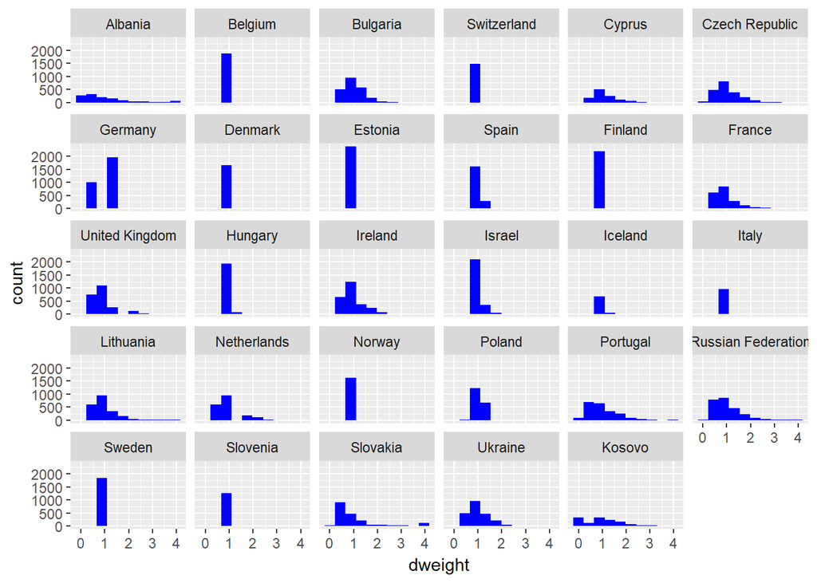

```r
library(ggplot2)
ggplot(ess2012, aes(dweight)) + geom_histogram(bins = 10, fill = "blue") +
  facet_wrap(~cntry)
```

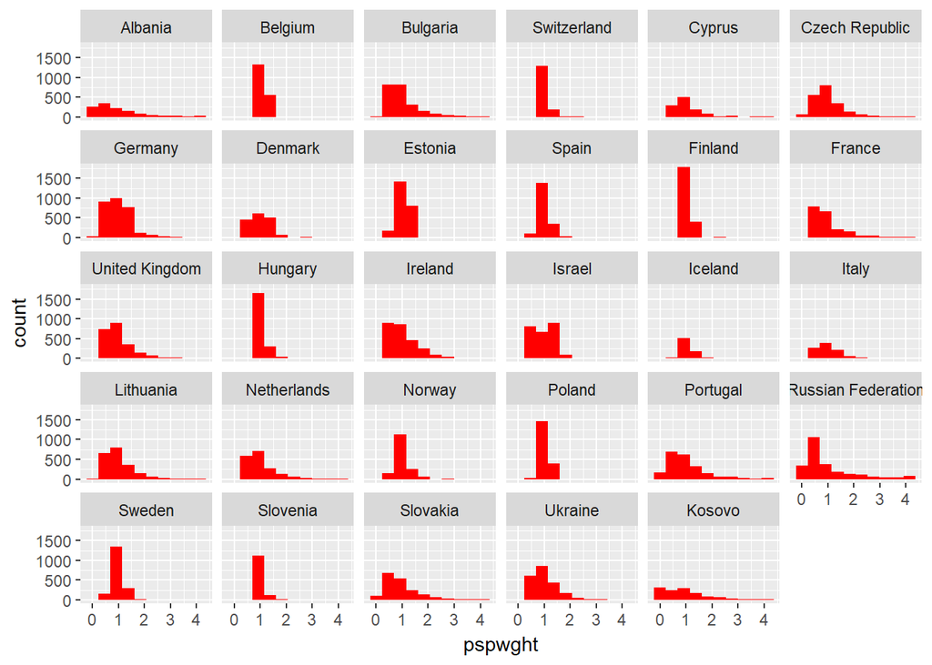

```r
ggplot(ess2012, aes(pspwght)) + geom_histogram(bins = 10, fill = "red") +
  facet_wrap(~cntry)
```

### Definiowanie schematu prostego i warstwowego

Jedyną rzeczą, która możemy zrobić z typowym zbiorem danych z socjologicznego sondażu, to **włączyć ważenie**. To też ważne, gdyż w niektórych badaniach występuje znaczne zróżnicowanie wag (prawdopodobieństw wyboru do próby) dla poszczególnych jednostek. Zastosowanie ważenie pozwala nam więc **uniknąć obciążenia**, choć **nie pozwoli adekwatnie szacować błędów standardowych**.

Jeśli analizujemy dane z wielu krajóW, powinniśmy też potraktować każdy kraj jako oddzielną warstwę.

Do opisu schematu doboru próby służy funkcja `svydesign()`. Zastosujmy ją do zbioru danych z wynikami badania ESS 2012.

**Dobór prosty**

Przy pomocy funkcji `svydesign()` możemy zdefiniować dobór prosty. - argument `ids` wskazuje zmienną, która opisuje przydział obserwacji w zbiorze do jednostek losowania kolejnych stopni; podaje się go w postaci prawostronnej formuły; - jeśli próba dobierana była jednostopniowo i indywidualnie (nie zespołowo), opisujemy ten fakt podając `ids = ~1`.

```r
library(survey)
ess2012prosty = svydesign(ids = ~1, data = ess2012)
print(ess2012prosty)
```

```
## Independent Sampling design (with replacement)
## svydesign(ids = ~1, data = ess2012)
```

```r
summary(ess2012prosty)
```

```
## Independent Sampling design (with replacement)
## svydesign(ids = ~1, data = ess2012)
## Probabilities:
##    Min. 1st Qu.  Median    Mean 3rd Qu.    Max.
##       1       1       1       1       1       1
## Data variables:
##   [1] "name"        "essround"    "edition"     "proddate"    "idno"
##   [6] "cntry"       "tvtot"       "tvpol"       "ppltrst"     "pplfair"
##  [11] "pplhlp"      "polintr"     "trstprl"     "trstlgl"     "trstplc"
##  [16] "trstplt"     "trstprt"     "trstep"      "trstun"      "vote"
##  [21] "prtvtal"     "prtvtcbe"    "prtvtcbg"    "prtvtdch"    "prtvtacy"
##  [26] "prtvtccz"    "prtvdde1"    "prtvdde2"    "prtvtcdk"    "prtvtdee"
##  [31] "prtvtces"    "prtvtcfi"    "prtvtcfr"    "prtvtgb"     "prtvtdhu"
##  [36] "prtvtaie"    "prtvtbil"    "prtvtais"    "prtvtbit"    "prtvalt1"
##  [41] "prtvalt2"    "prtvalt3"    "prtvtenl"    "prtvtano"    "prtvtcpl"
```

[output cut: 118 more lines]

Zobaczmy jeszcze, jaka jest struktura takiego obiektu.

```r
class(ess2012prosty)
```

```
## [1] "survey.design2" "survey.design"
```

```r
mode(ess2012prosty)
```

```
## [1] "list"
```

```r
names(ess2012prosty)
```

```
## [1] "cluster"    "strata"     "has.strata" "prob"       "allprob"
## [6] "call"       "variables"  "fpc"        "pps"
```

```r
all.equal(ess2012prosty$variables, ess2012)
```

```
## [1] TRUE
```

**Dobór z nierównymi prawdopodobieństwami**

Nierówne prawdopodobieństwa doboru możemy uwzględnić podając funkcji `svydesign()` jeden z argumentów `probs` lub `weights`. W postaci formuły wskazujemy przy ich pomocy zmienne opisujące prawdopodobieństwa lub wagi. - `probs` jeśli dysponujemy zmienną opisującą prawdopodobieństwa doboru jednostek do próby; - `weights` jeśli dysponujemy zmienną opisującą *sampling weights*; - w praktyce możemy tu bodać również zmienną opisującą *wagi analityczne*.

```r
ess2012dweight = svydesign(ids = ~1, weights = ~dweight,
                           data = ess2012)
ess2012dweight
```

```
## Independent Sampling design (with replacement)
## svydesign(ids = ~1, weights = ~dweight, data = ess2012)
```

Jeśli chcemy użyć wag poststratyfikacyjnych (nie uwzględniając wpływu poststratyfikacji na wielkość błędów standardowych), również używamy do tego argumentu `weights`.

```r
ess2012pspwght = svydesign(ids = ~1, weights = ~pspwght,
                           data = ess2012)
ess2012pspwght
```

```
## Independent Sampling design (with replacement)
## svydesign(ids = ~1, weights = ~pspwght, data = ess2012)
```

**Dobór warstwowy**

Warstwy definiujemy przy pomocy argumentu `strata`, podobnie jak w przypadku pozostałych podając formułą nazwę odpowiedniej zmiennej (lub zmiennych). W naszym przypadku jako oddzielne warstwy potraktujemy poszczególne kraje.

```r
ess2012warstw = svydesign(ids = ~1, strata = ~cntry,
                          weights = ~dweight, data = ess2012)
ess2012warstw
```

```
## Stratified Independent Sampling design (with replacement)
## svydesign(ids = ~1, strata = ~cntry, weights = ~dweight, data = ess2012)
```

### Przekształcanie danych

Pakiet *survey* udostępnia dwie podstawowe funkcje umożliwiające operowanie na obiektach `survey.design`.

- `subset()` umożliwia wybór podzbioru obserwacji i działa zupełnie analogicznie jak funkcja `subset()` dla ramek danych (a więc również bardzo analogicznie do funkcji `filter()` z pakietu *dplyr*);
- `update()` umożliwia przekształcanie zmiennych i dołączanie nowych zmiennych do zbioru danych; działa analogicznie do funkcji `mutate()` z pakietu *dplyr* (z tym że nie możemy w niej używać *helper functions* i innych specyficznie *dplyrowych* funkcjonalności).

**Wybierzmy dane z Polski**

```r
ess2012warstwPl = subset(ess2012warstw, cntry == "Poland")
```

**Dygresja o danych sondażowych (i tabela z rozkładem)**

W danych sondażowych przytłaczająca większość zmiennych nie jest ciągła, lecz ma charakter kategorialny - respondenci wskazywali odpowiedź spośród dosłownie kilku możliwych.

- Albo każda z odpowiedzi była opisana słownie (np. 1) *zdecydowanie tak*, 2) *raczej tak*, 3) *raczej nie*, 4) *zdecydowanie nie*).
- Albo na szerszej skali złożonej z liczb naturalnych (np. od 1 do 10 lub od 0 do 10).
- Występują też wartości wskazujące na *nieoczekiwane* przez badacza zachowanie respondenta: odmowy udzielenia odpowiedzi, czy odpowiedzi *nie wiem*.

Sprawdźmy, czy Polacy w 2012 r. byli szczęśliwi:

```r
subset(dictEss2012, variable == "happy")
```

```
##     variable             label
## 109    happy How happy are you
```

```r
rozklad = svytable(~happy, ess2012warstwPl)
rozklad
```

```
## happy
## Extremely unhappy                 1                 2                 3
##          9.531980         13.246578         23.049047         36.542738
##                 4                 5                 6                 7
##         54.864031        244.014404        165.639267        293.444519
##                 8                 9   Extremely happy           Refusal
##        492.646375        271.539064        270.815800          0.000000
##        Don't know         No answer
##          7.119693         15.546504
```

```r
class(rozklad)
```

```
## [1] "svytable" "xtabs"    "table"
```

Funkcja `svytable()` działa podobnie do funkcji `table()`, jednak uwzględnia schemat doboru próby (wagi). Konsekwentnie pomija też w zwracanych wynikach braki danych (i nie da się tego zmienić - nie ma argumentu analogicznego do `exclude`).

Obiekty zwracane przez `svytable()` zachowują się dosyć podobnie do obiektów klasy *table*, np.

```r
as.data.frame(prop.table(rozklad))
```

```
##                happy        Freq
## 1  Extremely unhappy 0.005022118
## 2                  1 0.006979229
## 3                  2 0.012143860
## 4                  3 0.019253287
## 5                  4 0.028906234
## 6                  5 0.128563964
## 7                  6 0.087270425
## 8                  7 0.154607228
## 9                  8 0.259560788
## 10                 9 0.143065893
## 11   Extremely happy 0.142684826
## 12           Refusal 0.000000000
## 13        Don't know 0.003751156
## 14         No answer 0.008190993
```

**Proste przekształcenia zmiennych**

Przekodujmy odpowiedzi *wymijające* i odmowy na braki danych.

```r
ess2012warstwPl =
  update(ess2012warstwPl,
         happy = factor(happy,
                        exclude = c("Refusal", "Don't know", "No answer")))
svytable(~happy, ess2012warstwPl)
```

```
## happy
## Extremely unhappy                 1                 2                 3
##           9.53198          13.24658          23.04905          36.54274
##                 4                 5                 6                 7
##          54.86403         244.01440         165.63927         293.44452
##                 8                 9   Extremely happy
##         492.64637         271.53906         270.81580
```

### Nieco bardziej złożony schemat

W odniesieniu do Polski możemy pozyskać dane potrzebne do opisania w wyczerpujący sposób schematu doboru próby do badania ESS.

```r
opisSchematuPl = read.csv2("dane/ESS6PL_dobor_proby.csv")
head(opisSchematuPl)
```

```
##   idno  cntry stratex1 czy_50plus n_psu    psu     prob_psu    prob_ind
## 1    2 Poland    65101       TRUE    10 100002 6.546902e-05 1.000000000
## 2    5 Poland    11200      FALSE    23  13509 1.109856e-02 0.005714286
## 3    6 Poland    90103       TRUE    10 100006 8.426588e-05 1.000000000
## 4    7 Poland    71902       TRUE    12 100007 5.590861e-05 1.000000000
## 5   15 Poland    56306       TRUE     4 100015 6.787254e-05 1.000000000
## 6   18 Poland    84703       TRUE    11 100018 8.657191e-05 1.000000000
##   pop15_stratex1
## 1         152744
## 2        1371799
## 3         118672
## 4         214636
## 5          58934
## 6         127062
```

- `idno`, `cntry` - zmienne identyfikacyjne, po których łączymy;
- `stratex1` - identyfikator warstwy;
- `czy_50plus` - czy warstwa obejmuje miasto powyżej 50 tys. mieszkańców?
- `n_psu` - liczba jednostek I stopnia losowanych w ramach warstwy;
- `psu` - identyfikator jednostki losowania I stopnia;
- `prob_psu` prawdopodobieństwo doboru jednostki losowania I stopnia;
- `prob_ind` prawdopodobieństwo doboru w ramach jednostki losowania I stopnia;
- `pop15_stratex1` - liczebność populacyjna warstwy;

Porównajmy jeszcze, jak wyglądają te informacje dla respondentów z warstw obejmujących miasta powyżej 50 tys. mieszkańców (gdzie dobór był jednostopniowy i w ramach warstw prosty) i pozostałych (gdzie najpierw losowano miejscowość, będącą jednostką losowania I stopnia, a w ramach wylosowanych miejscowości osoby).

```r
head(subset(opisSchematuPl, czy_50plus))
```

```
##   idno  cntry stratex1 czy_50plus n_psu    psu     prob_psu prob_ind
## 1    2 Poland    65101       TRUE    10 100002 6.546902e-05        1
## 3    6 Poland    90103       TRUE    10 100006 8.426588e-05        1
## 4    7 Poland    71902       TRUE    12 100007 5.590861e-05        1
## 5   15 Poland    56306       TRUE     4 100015 6.787254e-05        1
## 6   18 Poland    84703       TRUE    11 100018 8.657191e-05        1
## 7   24 Poland    79101       TRUE    13 100024 7.298123e-05        1
##   pop15_stratex1
## 1         152744
## 3         118672
## 4         214636
## 5          58934
## 6         127062
## 7         178128
```

```r
head(subset(opisSchematuPl, !czy_50plus))
```

```
##    idno  cntry stratex1 czy_50plus n_psu   psu    prob_psu     prob_ind
## 2     5 Poland    11200      FALSE    23 13509 0.011098565 0.0057142857
## 8    26 Poland    11400      FALSE    27 12934 0.003099081 0.0195121951
## 9    45 Poland    11200      FALSE    23 12746 0.011907174 0.0053262317
## 10   47 Poland    11200      FALSE    23 13509 0.011098565 0.0057142857
## 11   48 Poland    11200      FALSE    23 13512 0.012636509 0.0050188206
## 12   55 Poland    32200      FALSE     2 31911 0.112938387 0.0004242231
##    pop15_stratex1
## 2         1371799
## 8         1537956
## 9         1371799
## 10        1371799
## 11        1371799
## 12          83488
```

Widzimy, że aby w kompatybilny sposób opisać obie te sytuacje, w warstwach obejmujących miasta powyżej 50 tys. mieszkańców poszczególne osoby traktowane są jako jednostki losowania I stopnia, a w odniesieniu do II stopnia zakładamy, że *nic się tam nie dzieje* (w tym sensie, że jest on deterministyczny).

Przyłączmy te informacje do wyników z Polski i zdefiniujmy schemat.

```r
# żeby się dobrze łączyło, warto jeszcze uzgodnić poziomy czynnika
opisSchematuPl$cntry = factor(opisSchematuPl$cntry,
                              levels = levels(ess2012$cntry))
ess2012Pl = merge(subset(ess2012, cntry == "Poland"), opisSchematuPl)
# samo definiowanie schematu
ess2012Pl = svydesign(ids = ~psu + idno, probs = ~prob_psu + prob_ind,
                      strata = ~stratex1, data = ess2012Pl)
ess2012Pl
```

```
## Stratified 2 - level Cluster Sampling design (with replacement)
## With (1073, 1898) clusters.
## svydesign(ids = ~psu + idno, probs = ~prob_psu + prob_ind, strata = ~stratex1,
##     data = ess2012Pl)
```

Czy uzyskamy ten sam rozkład *szczęśliwości*?

```r
cbind(ess2012Pl = svytable(~happy, ess2012Pl),
      ess2012warstw = svytable(~happy, subset(ess2012warstw, cntry == "Poland")))
```

```
##                   ess2012Pl ess2012warstw
## Extremely unhappy  151302.3      9.531980
## 1                  239987.5     13.246578
## 2                  407459.9     23.049047
## 3                  619542.0     36.542738
## 4                  961916.9     54.864031
## 5                 4099905.2    244.014404
## 6                 2845232.6    165.639267
## 7                 5052910.1    293.444519
## 8                 8559624.0    492.646375
## 9                 4659910.6    271.539064
## Extremely happy   4426063.8    270.815800
## Refusal                 0.0      0.000000
## Don't know         136472.2      7.119693
## No answer          253417.7     15.546504
```

Coś się nie zgadza…

Pamiętacie, że jak mówiliśmy o estymatorach, to *pierwotnym*, od którego wyprowadzane są inne był estymator sumy populacyjnej? Otóż `svytable()` domyślnie zwraca oszacowania populacyjne - oczywiście o ile przy definiowaniu schematu podaliśmy prawdopodobieństwa albo prawdziwe *sampling weights*.

Możemy sobie z tym poradzić na jeden z dwóch sposobów - przechodząc na rozkłady częstości, albo używając argimentu `Ntotal` do podania sumy, do jakiej mają się sumować liczebności, przy wywołaniu `svytable()`.

```r
cbind(ess2012Pl = prop.table(svytable(~happy, ess2012Pl)),
      ess2012warstw = prop.table(svytable(~happy, subset(ess2012warstw,
                                                         cntry == "Poland"))))
```

```
##                     ess2012Pl ess2012warstw
## Extremely unhappy 0.004667845   0.005022118
## 1                 0.007403882   0.006979229
## 2                 0.012570591   0.012143860
## 3                 0.019113557   0.019253287
## 4                 0.029676204   0.028906234
## 5                 0.126486626   0.128563964
## 6                 0.087778584   0.087270425
## 7                 0.155887885   0.154607228
## 8                 0.264073897   0.259560788
## 9                 0.143763412   0.143065893
## Extremely happy   0.136548981   0.142684826
## Refusal           0.000000000   0.000000000
## Don't know        0.004210318   0.003751156
## No answer         0.007818219   0.008190993
```

```r
cbind(ess2012Pl = svytable(~happy, ess2012Pl, Ntotal = nrow(ess2012Pl$variables)),
      ess2012warstw = svytable(~happy, subset(ess2012warstw, cntry == "Poland")))
```

```
##                    ess2012Pl ess2012warstw
## Extremely unhappy   8.859569      9.531980
## 1                  14.052568     13.246578
## 2                  23.858982     23.049047
## 3                  36.277531     36.542738
## 4                  56.325435     54.864031
## 5                 240.071615    244.014404
## 6                 166.603753    165.639267
## 7                 295.875206    293.444519
## 8                 501.212257    492.646375
## 9                 272.862955    271.539064
## Extremely happy   259.169966    270.815800
## Refusal             0.000000      0.000000
## Don't know          7.991184      7.119693
## No answer          14.838979     15.546504
```

A jednak tak samo!

## Badanie PISA 2012

Zajmijmy się teraz badaniem, w którym wykorzystywane są wagi replikacyjne.

Wyniki z badania PISA 2012 ograniczyłem tylko do krajów, które przystąpiły do UE w XXI wieku - zbiór i tak jest dosyć duży.

```r
(load("dane/PISA2012.RData"))
```

```
## [1] "student2012"        "student2012weights" "dictStudent2012"
```

```r
head(dictStudent2012)
```

```
##   variable
## 1      CNT
## 2 SUBNATIO
## 3  STRATUM
## 4     OECD
## 5       NC
## 6 SCHOOLID
##                                                                                      label
## 1                                                                 Country code 3-character
## 2 Adjudicated sub-region code 7-digit code (3-digit country code + region ID + stratum ID)
## 3                           Stratum ID 7-character (cnt + region ID + original stratum ID)
## 4                                                                             OECD country
## 5                                                             National Centre 6-digit Code
## 6                           School ID 7-digit (region ID + stratum ID + 3-digit school ID)
```

```r
#str(student2012)
table(student2012$CNT)
```

```
##
##        Bulgaria  Czech Republic         Estonia         Croatia
##            5282            5327            4779            5008
##         Hungary       Lithuania          Latvia          Poland
##            4810            4618            4306            4607
##         Romania Slovak Republic        Slovenia
##            5074            4678            5911
```

```r
str(student2012weights)
```

```
## 'data.frame':    54400 obs. of  87 variables:
##  $ CNT       : Factor w/ 68 levels "Albania","United Arab Emirates",..: 7 7 7 7 7 7 7 7 7 7 ...
##  $ SCHOOLID  : Factor w/ 1471 levels "0000001","0000002",..: 1 1 1 1 1 1 1 1 1 1 ...
##  $ STIDSTD   : Factor w/ 33806 levels "00001","00002",..: 1 2 3 4 5 6 7 8 9 10 ...
##  $ W_FSTUWT  : num  20 19.8 19.8 20 19.8 ...
##  $ W_FSTR1   : num  10.01 9.92 9.92 10.01 9.92 ...
##  $ W_FSTR2   : num  30 29.7 29.7 30 29.7 ...
##  $ W_FSTR3   : num  10.2 10 10 10.2 10 ...
##  $ W_FSTR4   : num  29.4 29.3 29.3 29.4 29.3 ...
##  $ W_FSTR5   : num  30 29.7 29.7 30 29.7 ...
##  $ W_FSTR6   : num  10.2 10 10 10.2 10 ...
##  $ W_FSTR7   : num  10.01 9.92 9.92 10.01 9.92 ...
##  $ W_FSTR8   : num  29.4 29.3 29.3 29.4 29.3 ...
##  $ W_FSTR9   : num  30 29.7 29.7 30 29.7 ...
##  $ W_FSTR10  : num  30 29.7 29.7 30 29.7 ...
```

[output cut: 73 more lines]

### Definiowanie schematu replikacyjnego

Zmienne opisujące wagi replikacyjne bywają dostarczane w postaci oddzielnego zbioru, bywają też umieszczone razem ze zmiennymi opisującymi wyniki badania. W naszym przypadku znajdują się w oddzielnym obiekcie. Połączmy jeden z drugim, aby mieć pewność, że wiersze nie są w nich w innej kolejności.

```r
student2012 = merge(student2012, student2012weights)
rm(student2012weights)
```

Do definiowania schematów wykorzystujących różne rodzaje wag replikacyjnych służy funkcja `svrepdesign()`, której najważniejsze argumenty to:

```
- `repweights` pozwala wskazać, której zmienne opisują wagi replikacyjne; może to być formuła (zwykle mało użyteczne, bo zmiennych jest wiele), wyrażenie regularne, do którego będą pasować nazwy tych zmiennych lub ramka danych z tymi zmiennymi (musimy jednak mieć pewność, że jej wiersze są w tej samej kolejności, co dane);
- `weights` podaje nazwę zmiennej zawierającej *sampling weights* (lub *wagi analityczne*);
- `combined.weights` pozwala wskazać, czy zmienne zawierające wagi replikacyjne (wynikające ze schematu replikacji) zostały już wcześniej przemnożone przez *sampling weights*, czy też nie;
  - uwaga, nawet jeśli `combined.weights=TRUE`, wciąż musimy podać argument `weights`;
- `type` służy do podania typu wag (BRR, jacknife, bootstrap);
- `rho` służy do podania wartości parametru Fay'a (jeśli posługujemy się wagami typu BRR);
- `data` służy do przekazania ramki danych z danymi (i ew. również wagami).
```

W przypadku badania PISA 2012 mamy do czynienia z:

- Wagami typu BRR z poprawką Fay’a równą 0,5.
- Nazwy zmiennych opisujących wagi replikacyjne zaczynają się od *W_FSTR*.
- Zmienna opisująca *sampling weights* to `W_FSTUWT`.

Czy zmienne zawierające wagi replikacyjne zostały już przemnożone przez *sampling weights*? Sprawdźmy:

```r
summary(student2012$W_FSTR1)
```

```
##     Min.  1st Qu.   Median     Mean  3rd Qu.     Max.
##   0.6143   3.5456   8.5961  17.0954  16.1639 306.7043
```

Możemy więc zdefiniować schemat replikacyjny:

```r
student2012rep = svrepdesign(repweights = "^W_FSTR", weights = ~W_FSTUWT,
                             type = "BRR", rho = 0.5, combined.weights = TRUE,
                             data = student2012)
student2012rep
```

```
## Call: svrepdesign.default(repweights = "^W_FSTR", weights = ~W_FSTUWT,
##     type = "BRR", rho = 0.5, combined.weights = TRUE, data = student2012)
## Balanced Repeated Replicates with 80 replicates.
```

Do porównań na przyszłość zdefiniujmy sobie również schematy: 1) prosty oraz 2) warstwowany po krajach, z uwzględnieniem *design weights*, ale nie doboru wielostopniowego.

```r
student2012prosty = svydesign(ids = ~1, weights = ~1, data = student2012)
student2012warstw = svydesign(ids = ~1, strata = ~CNT, weights = ~W_FSTUWT,
                              data = student2012)
```

# 2. Estymacja typowych statystyk

Pakiet *survey* udostępnia kilka funkcji pozwalających obliczać najczęściej wykorzystywane statystyki:

- średnie: `svymean()`;
- kwantyle: `svyquantile()`;
- wariancje i kowariancje: `svyvar()`;

Każda z tych funkcji domyślnie oblicza również błędy standardowe szacowanych parametrów.

Funkcje wymagają podania:

- zmiennych, dla których mają być obliczone statystyki - w postaci prawostronnej formuły;
  - może ich być kilka na raz;
- obiektu ze schematem doboru próby (zawierającego te zmienne);
- jeśli w zmiennych występują braki danych, wywołanie funkcji zwróci `NA` (schematy opisane *explicite*) lub zakończy się błędem (schematy replikacyjne);
  - chyba że użyjemy argumentu `na.rm=TRUE`;
  - jeśli podaliśmy kilka zmiennych oraz argument `na.rm=TRUE`, przed obliczeniem parametróW, **z danych usunięte zostaną wszystkie wiersze, w których występuje brak danych w chociaż jednej z podanych zmiennych**;

## Kilka analiz na polskich danych ESS

W ESS mamy zestaw pytań o zaufanie do różnego rodzaju instytucji:

```r
subset(dictEss2012, grepl("^trst", dictEss2012$variable))
```

```
##    variable                            label
## 13  trstprl    Trust in country's parliament
## 14  trstlgl        Trust in the legal system
## 15  trstplc              Trust in the police
## 16  trstplt             Trust in politicians
## 17  trstprt       Trust in political parties
## 18   trstep Trust in the European Parliament
## 19   trstun      Trust in the United Nations
```

```r
svytable(~trstprl, ess2012Pl)
```

```
## trstprl
## No trust at all               1               2               3
##       5868660.0       3923575.4       5005290.7       4848875.8
##               4               5               6               7
##       2826098.2       4871049.6       1768622.4       1025008.2
##               8               9  Complete trust         Refusal
##        732136.9        329832.3        355952.9             0.0
##      Don't know       No answer
##        858642.5             0.0
```

Postąpimy z nimi nieco brutalnie i na potrzeby analizy potraktujemy je jako zmienne ciągłe (odpowiedzi *wymijające* przekodowując na braki danych). Odpowiednio przekształcone zmienne znajdują się już w naszych danych (choć nie ma ich w ramce danych ze *słownikiem*): ich nazwy mają dodany przyrostek *_mod*.

```r
zmienne = grep("^trst.*_mod", names(ess2012), value = TRUE)
zmienne
```

```
## [1] "trstprl_mod" "trstlgl_mod" "trstplc_mod" "trstplt_mod" "trstprt_mod"
## [6] "trstep_mod"  "trstun_mod"
```

```r
svytable(~trstprl_mod, ess2012Pl)
```

```
## trstprl_mod
##         0         1         2         3         4         5         6
## 5868660.0 3923575.4 5005290.7 4848875.8 2826098.2 4871049.6 1768622.4
##         7         8         9        10
## 1025008.2  732136.9  329832.3  355952.9
```

### Średnie

Oszacujmy srednie wartości deklaracji nt. zaufania do poszczególnych instytucji w Polsce:

```r
zmienneFormula = make.formula(zmienne)
(srProsty = svymean(zmienneFormula,
                    subset(ess2012prosty, cntry == "Poland"), na.rm =  TRUE))
```

```
##               mean     SE
## trstprl_mod 2.9599 0.0591
## trstlgl_mod 3.6664 0.0606
## trstplc_mod 5.1591 0.0651
## trstplt_mod 2.2774 0.0520
## trstprt_mod 2.2874 0.0520
## trstep_mod  4.2266 0.0639
## trstun_mod  5.0314 0.0659
```

```r
(srDweight = svymean(zmienneFormula,
                     subset(ess2012dweight, cntry == "Poland"), na.rm =  TRUE))
```

```
##               mean     SE
## trstprl_mod 2.9448 0.0596
## trstlgl_mod 3.6618 0.0613
## trstplc_mod 5.1675 0.0658
## trstplt_mod 2.2883 0.0531
## trstprt_mod 2.2931 0.0527
## trstep_mod  4.2192 0.0645
## trstun_mod  5.0269 0.0667
```

```r
(srPspwght = svymean(zmienneFormula,
                     subset(ess2012pspwght, cntry == "Poland"), na.rm =  TRUE))
```

```
##               mean     SE
## trstprl_mod 2.9491 0.0594
## trstlgl_mod 3.6694 0.0612
## trstplc_mod 5.1678 0.0658
## trstplt_mod 2.2853 0.0531
## trstprt_mod 2.2934 0.0528
## trstep_mod  4.2313 0.0647
## trstun_mod  5.0353 0.0666
```

```r
(srSch = svymean(zmienneFormula, ess2012Pl, na.rm =  TRUE))
```

```
##               mean     SE
## trstprl_mod 2.9835 0.0623
## trstlgl_mod 3.6905 0.0630
## trstplc_mod 5.1599 0.0693
## trstplt_mod 2.2878 0.0564
## trstprt_mod 2.2968 0.0564
## trstep_mod  4.2482 0.0685
## trstun_mod  5.0497 0.0692
```

Łatwiej będzie nam to zobaczyć na wykresie. Poniżej trochę przekształceń (nie całkiem eleganckich), które zbierają powyższe wyniki w jedną ramkę danych.

```r
srednie = rbind(
  cbind(ftable(srProsty), schemat = "prosty"),
  cbind(ftable(srDweight), schemat = "dweight"),
  cbind(ftable(srPspwght), schemat = "pspwght"),
  cbind(ftable(srSch), schemat = "pełen schemat"))
colnames(srednie) = c("srednia", "blad.standardowy", "schemat")
srednie = data.frame(variable = rownames(srednie), srednie,
                     row.names = 1:nrow(srednie), stringsAsFactors = FALSE)
srednie$srednia = as.numeric(srednie$srednia)
srednie$blad.standardowy = as.numeric(srednie$blad.standardowy)

etykiety = subset(dictEss2012, grepl("^trst", dictEss2012$variable))
etykiety$label = sub("^.*(in|in the) ", "", etykiety$label)
etykiety$variable = paste0(etykiety$variable, "_mod")
srednie = merge(etykiety, srednie)
```

Teraz możemy rysować.

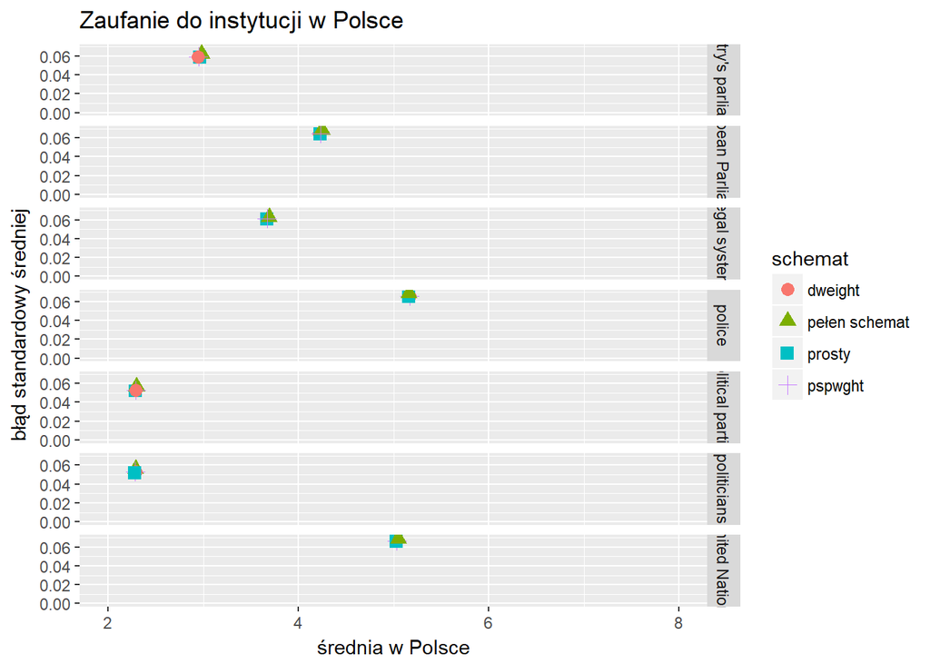

```r
ggplot(srednie, aes(srednia, blad.standardowy, shape = schemat, colour = schemat)) +
  geom_point(size = 3) +
  facet_grid(label ~ .) +
  scale_x_continuous(name = "średnia w Polsce", limits = c(2, 8)) +
  scale_y_continuous(name = "błąd standardowy średniej", limits = c(0, NA)) +
  ggtitle("Zaufanie do instytucji w Polsce")
```

Jak widać, **w odniesieniu do zmiennych opisujących zaufanie**, w Polsce dla oszacowań punktowych generalnie nie ma znaczenia, jak zdefiniujemy schemat. Nie opisując w pełen sposób schematu doboru zaniżamy co prawda oszacowania błędów standardowych… ale i to nie są ogromne różnice.

Gdybyśmy potrzebowali wyznaczyć przedziały ufności dla oszacowanych średnich, możemy zrobić to łatwo przy pomocy funkcji `confint()`, np:

```r
(puSrednieSch = confint(srSch, level = 0.95))
```

```
##                2.5 %   97.5 %
## trstprl_mod 2.861459 3.105521
## trstlgl_mod 3.567089 3.813990
## trstplc_mod 5.024174 5.295703
## trstplt_mod 2.177326 2.398229
## trstprt_mod 2.186353 2.407295
## trstep_mod  4.113956 4.382389
## trstun_mod  4.913959 5.185404
```

```r
str(puSrednieSch)
```

```
##  num [1:7, 1:2] 2.86 3.57 5.02 2.18 2.19 ...
##  - attr(*, "dimnames")=List of 2
##   ..$ : chr [1:7] "trstprl_mod" "trstlgl_mod" "trstplc_mod" "trstplt_mod" ...
##   ..$ : chr [1:2] "2.5 %" "97.5 %"
```

### Funkcja svyby()

Czy podobne wyniki jak przed chwilą uzyskamy w każdym kraju?

Wybierzmy jedną zmienną, za to rozpatrzmy wszystkie kraje. Teraz będziemy w stanie przyjrzeć się tylko wpływowi zastosowanych wag - w odniesieniu do innych krajów niż Polska nie mamy danych pozwalających w wyczerpujący sposób opisać schematy losowania.

Funkcja `svyby()` pozwala w wygodny sposób prowadzić analizy w podgrupach:

- jako pierwszy argument podajemy (typowo w formie prawostronnej formuły) zmienne, które mają być analizowane;
- jako drugi argument (typowo w formie prawostronnej formuły) zmienne wyznaczające podział na podgrupy;
- jako trzeci argument podajemy obiekt ze schematem doboru próby;
- jako czwarty argument funkcję, która ma być wykorzystana do analiz;
- ew. dalsze argumenty (koniecznie trzeba je nazywać) zostaną przekazane do ww. funkcji;

```r
zmienna = "trstplc_mod"
(srProsty = svyby(make.formula(zmienna), ~cntry, ess2012prosty, svymean, na.rm = TRUE))
```

```
##                                 cntry trstplc_mod         se
## Albania                       Albania    4.912134 0.09850345
## Belgium                       Belgium    6.120579 0.04897610
## Bulgaria                     Bulgaria    3.515235 0.06266849
## Switzerland               Switzerland    7.158923 0.05169245
## Cyprus                         Cyprus    5.078040 0.08405199
## Czech Republic         Czech Republic    5.104995 0.05862167
## Germany                       Germany    6.836555 0.03919988
## Denmark                       Denmark    7.954380 0.04257763
## Estonia                       Estonia    5.901155 0.05179600
## Spain                           Spain    5.879467 0.05691186
## Finland                       Finland    8.097039 0.03392910
## France                         France    5.930315 0.05051670
## United Kingdom         United Kingdom    6.528944 0.04670701
## Hungary                       Hungary    5.337067 0.05443798
## Ireland                       Ireland    6.658873 0.04468666
## Israel                         Israel    5.122549 0.05457303
## Iceland                       Iceland    7.807487 0.06495072
## Italy                           Italy    6.111579 0.08276580
## Lithuania                   Lithuania    5.521376 0.05546963
## Netherlands               Netherlands    6.404360 0.04275786
## Norway                         Norway    7.155652 0.04722164
## Poland                         Poland    5.248788 0.05836556
## Portugal                     Portugal    5.370370 0.05332984
## Russian Federation Russian Federation    3.485774 0.05239540
## Sweden                         Sweden    6.720652 0.04745581
## Slovenia                     Slovenia    5.383495 0.07135521
## Slovakia                     Slovakia    4.147864 0.05857572
## Ukraine                       Ukraine    2.045823 0.05132500
## Kosovo                         Kosovo    4.677215 0.09577221
```

```r
(srDweight = svyby(make.formula(zmienna), ~cntry, ess2012dweight, svymean, na.rm = TRUE))
```

```
##                                 cntry trstplc_mod         se
## Albania                       Albania    4.894448 0.13479209
## Belgium                       Belgium    6.120579 0.04897610
## Bulgaria                     Bulgaria    3.563795 0.06759892
## Switzerland               Switzerland    7.158923 0.05169245
## Cyprus                         Cyprus    4.935966 0.09390156
## Czech Republic         Czech Republic    5.139421 0.06465937
## Germany                       Germany    6.931175 0.04037337
## Denmark                       Denmark    7.954380 0.04257763
## Estonia                       Estonia    5.901155 0.05179600
## Spain                           Spain    5.869817 0.05720557
## Finland                       Finland    8.097039 0.03392910
## France                         France    5.937544 0.05849271
## United Kingdom         United Kingdom    6.548500 0.05119608
## Hungary                       Hungary    5.334914 0.05472482
## Ireland                       Ireland    6.638198 0.05005159
## Israel                         Israel    5.117274 0.05566172
## Iceland                       Iceland    7.821552 0.06519248
## Italy                           Italy    6.111579 0.08276580
## Lithuania                   Lithuania    5.481629 0.06329600
## Netherlands               Netherlands    6.407941 0.04751451
## Norway                         Norway    7.155652 0.04722164
## Poland                         Poland    5.268471 0.05892034
## Portugal                     Portugal    5.316286 0.06404955
## Russian Federation Russian Federation    3.517438 0.06058099
## Sweden                         Sweden    6.720652 0.04745581
## Slovenia                     Slovenia    5.383495 0.07135521
## Slovakia                     Slovakia    4.133108 0.07804545
## Ukraine                       Ukraine    2.039353 0.05785978
## Kosovo                         Kosovo    5.602004 0.10583302
```

```r
(srPspwght = svyby(make.formula(zmienna), ~cntry, ess2012pspwght, svymean, na.rm = TRUE))
```

```
##                                 cntry trstplc_mod         se
## Albania                       Albania    4.905747 0.13727674
## Belgium                       Belgium    6.083637 0.05095774
## Bulgaria                     Bulgaria    3.491339 0.07403002
## Switzerland               Switzerland    7.153405 0.05335423
## Cyprus                         Cyprus    4.843223 0.10144746
## Czech Republic         Czech Republic    5.093553 0.06722046
## Germany                       Germany    6.912896 0.04508189
## Denmark                       Denmark    7.936867 0.04640609
## Estonia                       Estonia    5.914411 0.05188146
## Spain                           Spain    5.859849 0.05829320
## Finland                       Finland    8.074681 0.03625704
## France                         France    5.927594 0.06455020
## United Kingdom         United Kingdom    6.548552 0.05383867
## Hungary                       Hungary    5.316355 0.05632648
## Ireland                       Ireland    6.626130 0.05167192
## Israel                         Israel    5.082810 0.06173925
## Iceland                       Iceland    7.808895 0.06651892
## Italy                           Italy    6.230030 0.08902358
## Lithuania                   Lithuania    5.463983 0.06552652
## Netherlands               Netherlands    6.405702 0.05304714
## Norway                         Norway    7.149891 0.05290280
## Poland                         Poland    5.264017 0.05905398
## Portugal                     Portugal    5.339590 0.06520167
## Russian Federation Russian Federation    3.589271 0.07278475
## Sweden                         Sweden    6.704146 0.05073592
## Slovenia                     Slovenia    5.326187 0.07407730
## Slovakia                     Slovakia    4.104569 0.06909913
## Ukraine                       Ukraine    2.035334 0.05950247
## Kosovo                         Kosovo    5.724578 0.11111214
```

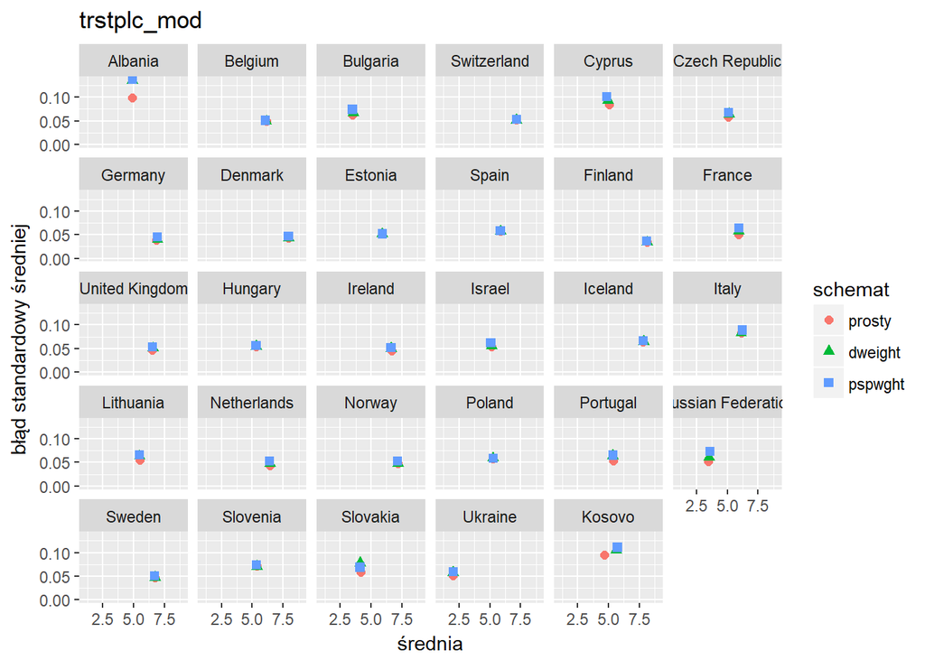

```r
srednie = rbind(
  cbind(srProsty, schemat = "prosty"),
  cbind(srDweight, schemat = "dweight"),
  cbind(srPspwght, schemat = "pspwght")
)
ggplot(srednie, aes_string(zmienna, "se", shape = "schemat", colour = "schemat")) +
  geom_point(size = 2) +
  facet_wrap(~cntry) +
  scale_x_continuous(name = "średnia", limits = c(1, 9)) +
  scale_y_continuous(name = "błąd standardowy średniej", limits = c(0, NA)) +
  ggtitle(zmienna)
```

```r
#View(srednie)
```

Ważenie wciąż niewiele zmienia w zakresie oszacowań punktowych (**uwaga! w dużej mierze wynika to z faktu, że operujemy na dużej liczbie obserwacji**, przy prowadzeniu analiz na mniejszych podgrupach te różnice mogłyby być dużo większe), choć miewa spory wpływ na szacowane błędy standardowe (które zwiększają się w związku z występowaniem nierównych wag).

Funkcja `confint()` działa również na obiektach zwracanych przez `svyby()`:

```r
confint(srPspwght, level = 0.95)
```

```
##                       2.5 %   97.5 %
## Albania            4.636690 5.174805
## Belgium            5.983761 6.183512
## Bulgaria           3.346243 3.636435
## Switzerland        7.048832 7.257977
## Cyprus             4.644390 5.042056
## Czech Republic     4.961804 5.225303
## Germany            6.824538 7.001255
## Denmark            7.845913 8.027822
## Estonia            5.812725 6.016097
## Spain              5.745597 5.974102
## Finland            8.003618 8.145743
## France             5.801078 6.054110
## United Kingdom     6.443030 6.654074
## Hungary            5.205957 5.426752
## Ireland            6.524855 6.727405
## Israel             4.961803 5.203817
## Iceland            7.678520 7.939270
## Italy              6.055547 6.404513
## Lithuania          5.335554 5.592413
## Netherlands        6.301732 6.509673
## Norway             7.046203 7.253578
## Poland             5.148273 5.379761
## Portugal           5.211797 5.467383
## Russian Federation 3.446616 3.731927
## Sweden             6.604706 6.803587
## Slovenia           5.180998 5.471375
## Slovakia           3.969137 4.240000
## Ukraine            1.918711 2.151957
## Kosovo             5.506802 5.942353
```

Z kolei funkcji `ftable()` możemy użyć, by nieco inaczej sformatować macierz z wynikami (co może być pomocne, gdy chcemy ją gdzieś przekleić):

```r
ftable(srPspwght)
```

```
##                             trstplc_mod
## cntry
## Albania            svymean   4.90574715
##                    SE        0.13727674
## Belgium            svymean   6.08363652
##                    SE        0.05095774
## Bulgaria           svymean   3.49133870
##                    SE        0.07403002
## Switzerland        svymean   7.15340478
##                    SE        0.05335423
## Cyprus             svymean   4.84322297
##                    SE        0.10144746
## Czech Republic     svymean   5.09355338
##                    SE        0.06722046
## Germany            svymean   6.91289649
##                    SE        0.04508189
## Denmark            svymean   7.93686736
##                    SE        0.04640609
## Estonia            svymean   5.91441093
##                    SE        0.05188146
## Spain              svymean   5.85984917
##                    SE        0.05829320
## Finland            svymean   8.07468071
##                    SE        0.03625704
## France             svymean   5.92759424
##                    SE        0.06455020
## United Kingdom     svymean   6.54855219
##                    SE        0.05383867
## Hungary            svymean   5.31635451
##                    SE        0.05632648
## Ireland            svymean   6.62612993
##                    SE        0.05167192
## Israel             svymean   5.08280986
##                    SE        0.06173925
## Iceland            svymean   7.80889486
##                    SE        0.06651892
## Italy              svymean   6.23003013
##                    SE        0.08902358
## Lithuania          svymean   5.46398341
##                    SE        0.06552652
## Netherlands        svymean   6.40570225
##                    SE        0.05304714
## Norway             svymean   7.14989059
##                    SE        0.05290280
## Poland             svymean   5.26401714
##                    SE        0.05905398
## Portugal           svymean   5.33958967
##                    SE        0.06520167
## Russian Federation svymean   3.58927110
##                    SE        0.07278475
## Sweden             svymean   6.70414621
##                    SE        0.05073592
## Slovenia           svymean   5.32618660
##                    SE        0.07407730
## Slovakia           svymean   4.10456857
##                    SE        0.06909913
## Ukraine            svymean   2.03533395
##                    SE        0.05950247
## Kosovo             svymean   5.72457756
##                    SE        0.11111214
```

### Kiedy ważenie robi dużą różnicę?

Rozpatrzmy jednak jeszcze jedną zmienną: liczba członków gospodarstwa domowego (respondenta). W postaci przekształconej na zmienną ciągłą (z czynnika) nazywa się ona w naszym zbiorze `hhmmb_mod`.

```r
zmienna = "hhmmb_mod"
(srProsty = svyby(make.formula(zmienna), ~cntry, ess2012prosty, svymean, na.rm = TRUE))
```

```
##                                 cntry hhmmb_mod         se
## Albania                       Albania  4.064489 0.05152016
## Belgium                       Belgium  2.842697 0.03337854
## Bulgaria                     Bulgaria  2.564159 0.02855876
## Switzerland               Switzerland  2.742800 0.03456598
## Cyprus                         Cyprus  2.818100 0.03893582
## Czech Republic         Czech Republic  2.583375 0.02741904
## Germany                       Germany  2.596069 0.02424414
## Denmark                       Denmark  2.576364 0.03114542
## Estonia                       Estonia  2.570168 0.02796995
## Spain                           Spain  3.067338 0.03008988
## Finland                       Finland  2.397360 0.02906006
## France                         France  2.342480 0.02979060
## United Kingdom         United Kingdom  2.381619 0.02743288
## Hungary                       Hungary  2.685204 0.03271224
## Ireland                       Ireland  2.762177 0.02759856
## Israel                         Israel  3.686228 0.03703664
## Iceland                       Iceland  3.104139 0.05572254
## Italy                           Italy  3.002083 0.04274676
## Lithuania                   Lithuania  2.435277 0.02508323
## Netherlands               Netherlands  2.325745 0.03019356
## Norway                         Norway  2.695625 0.03357664
## Poland                         Poland  3.231379 0.03505183
## Portugal                     Portugal  2.454207 0.02618051
## Russian Federation Russian Federation  2.505636 0.02581830
## Sweden                         Sweden  2.585273 0.03146001
## Slovenia                     Slovenia  3.167331 0.04119537
## Slovakia                     Slovakia  2.796968 0.03305284
## Ukraine                       Ukraine  2.720257 0.02928575
## Kosovo                         Kosovo  4.955985 0.07365783
```

```r
(srDweight = svyby(make.formula(zmienna), ~cntry, ess2012dweight, svymean, na.rm = TRUE))
```

```
##                                 cntry hhmmb_mod         se
## Albania                       Albania  4.447919 0.06712009
## Belgium                       Belgium  2.842697 0.03337854
## Bulgaria                     Bulgaria  2.956146 0.03578956
## Switzerland               Switzerland  2.742800 0.03456598
## Cyprus                         Cyprus  3.296189 0.04558934
## Czech Republic         Czech Republic  3.046895 0.03387608
## Germany                       Germany  2.667228 0.02629363
## Denmark                       Denmark  2.576364 0.03114542
## Estonia                       Estonia  2.570168 0.02796995
## Spain                           Spain  3.067870 0.03013915
## Finland                       Finland  2.397360 0.02906006
## France                         France  2.822282 0.04135063
## United Kingdom         United Kingdom  2.809725 0.03797169
## Hungary                       Hungary  2.684829 0.03270978
## Ireland                       Ireland  3.254580 0.03315563
## Israel                         Israel  3.694851 0.03833064
## Iceland                       Iceland  3.108447 0.05723444
## Italy                           Italy  3.002083 0.04274676
## Lithuania                   Lithuania  2.839641 0.03164939
## Netherlands               Netherlands  2.775989 0.03984850
## Norway                         Norway  2.695625 0.03357664
## Poland                         Poland  3.260403 0.03601331
## Portugal                     Portugal  2.924992 0.03663812
## Russian Federation Russian Federation  3.037470 0.03536646
## Sweden                         Sweden  2.585273 0.03146001
## Slovenia                     Slovenia  3.167331 0.04119537
## Slovakia                     Slovakia  3.153877 0.04112863
## Ukraine                       Ukraine  3.235176 0.04092030
## Kosovo                         Kosovo  6.308621 0.13779688
```

```r
(srPspwght = svyby(make.formula(zmienna), ~cntry, ess2012pspwght, svymean, na.rm = TRUE))
```

```
##                                 cntry hhmmb_mod         se
## Albania                       Albania  4.532467 0.07410703
## Belgium                       Belgium  2.809477 0.03417683
## Bulgaria                     Bulgaria  3.059838 0.03737667
## Switzerland               Switzerland  2.750181 0.03549275
## Cyprus                         Cyprus  3.313185 0.04765932
## Czech Republic         Czech Republic  2.957885 0.03452540
## Germany                       Germany  2.642335 0.02832414
## Denmark                       Denmark  2.590849 0.03448460
## Estonia                       Estonia  2.635840 0.02876156
## Spain                           Spain  3.065532 0.03084834
## Finland                       Finland  2.435748 0.03121114
## France                         France  2.818516 0.04340082
## United Kingdom         United Kingdom  2.876350 0.03967248
## Hungary                       Hungary  2.713440 0.03430531
## Ireland                       Ireland  3.283716 0.03369305
## Israel                         Israel  3.859321 0.04104424
## Iceland                       Iceland  3.095353 0.05741450
## Italy                           Italy  2.958368 0.04748755
## Lithuania                   Lithuania  2.798583 0.03167967
## Netherlands               Netherlands  2.811920 0.04486633
## Norway                         Norway  2.717625 0.03748600
## Poland                         Poland  3.274846 0.03590855
## Portugal                     Portugal  2.950034 0.03675844
## Russian Federation Russian Federation  2.924215 0.03837811
## Sweden                         Sweden  2.610939 0.03675293
## Slovenia                     Slovenia  3.214145 0.04253816
## Slovakia                     Slovakia  3.329011 0.04576248
## Ukraine                       Ukraine  3.263480 0.04062201
## Kosovo                         Kosovo  6.249535 0.12803968
```

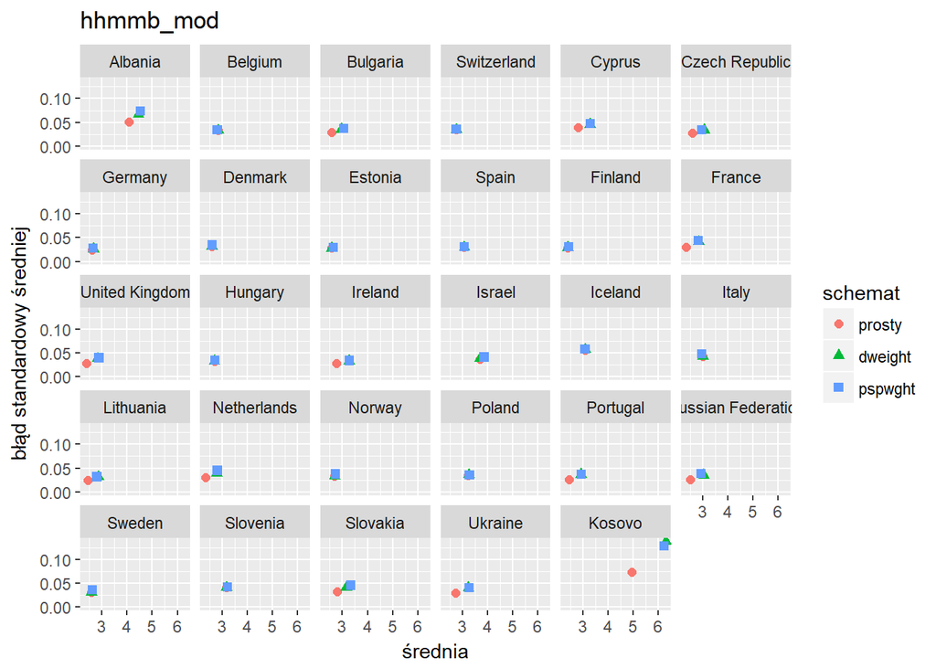

```r
srednie = rbind(
  cbind(srProsty, schemat = "prosty"),
  cbind(srDweight, schemat = "dweight"),
  cbind(srPspwght, schemat = "pspwght")
)
ggplot(srednie, aes_string(zmienna, "se", shape = "schemat", colour = "schemat")) +
  geom_point(size = 2) +
  facet_wrap(~cntry) +
  scale_x_continuous(name = "średnia") +
  scale_y_continuous(name = "błąd standardowy średniej", limits = c(0, NA)) +
  ggtitle(zmienna)
```

```r
#View(srednie)
```

Dlaczego w jednych krajach widać tak wyraźne różnice, a w innych nie?

```r
# we Francji różnica dla `hhmmb_mod` jest znaczna
round(cor(subset(ess2012, cntry == "France")
          [, c("dweight", "pspwght", "trstplc_mod", "hhmmb_mod")],
          use = "pairwise.complete.obs"), 2)
```

```
##             dweight pspwght trstplc_mod hhmmb_mod
## dweight        1.00    0.75        0.01      0.69
## pspwght        0.75    1.00        0.00      0.54
## trstplc_mod    0.01    0.00        1.00      0.03
## hhmmb_mod      0.69    0.54        0.03      1.00
```

```r
# a w Polsce nie
round(cor(subset(ess2012, cntry == "Poland")
          [, c("dweight", "pspwght", "trstplc_mod", "hhmmb_mod")],
          use = "pairwise.complete.obs"), 2)
```

```
##             dweight pspwght trstplc_mod hhmmb_mod
## dweight        1.00    0.82        0.06      0.14
## pspwght        0.82    1.00        0.04      0.18
## trstplc_mod    0.06    0.04        1.00      0.03
## hhmmb_mod      0.14    0.18        0.03      1.00
```

### (Ko)wariancje i odchylenia standardowe

Funkcja `svyvar()` charakteryzuje się tym, że estymuje macierz kowariancji pomiędzy podanymi zmiennymi, choć łatwo może nam to umknąć, gdyż metoda `print()` dla zwracanego przez nią obiektu wyświetla jedynie wariancje (a więc wartości z przekątnej wyestymowanej i zwróconej przez funkcję macierzy).

Jako atrybut obiektu otrzymujemy również macierz z oszacowaniami wariancji estymatoróW (ko)wariancji.

```r
zmienneFormula
```

```
## ~trstprl_mod + trstlgl_mod + trstplc_mod + trstplt_mod + trstprt_mod +
##     trstep_mod + trstun_mod
## <environment: 0x00000000156a7a80>
```

```r
(warSch = svyvar(zmienneFormula,
                 subset(ess2012Pl, cntry == "Poland"), na.rm =  TRUE))
```

```
##             variance     SE
## trstprl_mod   5.2786 0.1911
## trstlgl_mod   5.5113 0.1698
## trstplc_mod   6.2967 0.1993
## trstplt_mod   4.0671 0.1672
## trstprt_mod   4.1024 0.1655
## trstep_mod    6.1575 0.1923
## trstun_mod    6.4577 0.1999
```

```r
str(warSch)
```

```
##  svyvar [1:7, 1:7] 5.28 3.27 2.24 3.19 3 ...
##  - attr(*, "dimnames")=List of 2
##   ..$ : chr [1:7] "trstprl_mod" "trstlgl_mod" "trstplc_mod" "trstplt_mod" ...
##   ..$ : chr [1:7] "trstprl_mod" "trstlgl_mod" "trstplc_mod" "trstplt_mod" ...
##  - attr(*, "var")= num [1:49, 1:49] 0.0365 0.0227 0.0116 0.0194 0.0176 ...
##   ..- attr(*, "dimnames")=List of 2
##   .. ..$ : chr [1:49] "trstprl_mod" "trstprl_mod" "trstprl_mod" "trstprl_mod" ...
##   .. ..$ : chr [1:49] "trstprl_mod" "trstprl_mod" "trstprl_mod" "trstprl_mod" ...
##  - attr(*, "statistic")= chr "variance"
```

Chcąc przejść do oszacowań odchyleń standardowych musimy spierwiastkować przekątną zwróconej macierzy:

```r
(odchStdSch = diag(warSch)^0.5)
```

```
## trstprl_mod trstlgl_mod trstplc_mod trstplt_mod trstprt_mod  trstep_mod
##    2.297512    2.347607    2.509316    2.016709    2.025437    2.481434
##  trstun_mod
##    2.541192
```

### Kwantyle

Do obliczania kwantyli służy funkcja `svyquantile()`. Warto odnotować, że posiada ono kilka specyficznych argumentów umożliwiających szacowanie rozsądniejszych przedziałów ufności dla kwantyli (te oparte na aproksymacji normalnej są adekwatne tylko dla kwantyli bliskich 0,5) - nie będziemy ich tu jednak omawiać.

```r
svyquantile(~hhmmb_mod, ess2012Pl, c(0.25, 0.5, 0.75), na.rm = TRUE)
```

```
##           0.25 0.5 0.75
## hhmmb_mod    2   3    4
```

```r
svyquantile(zmienneFormula, ess2012Pl, c(0.25, 0.5, 0.75), na.rm = TRUE)
```

```
##             0.25 0.5 0.75
## trstprl_mod    1   3    5
## trstlgl_mod    2   4    5
## trstplc_mod    3   5    7
## trstplt_mod    1   2    4
## trstprt_mod    0   2    4
## trstep_mod     2   5    6
## trstun_mod     3   5    7
```

### Tabele krzyżowe

Przy pomocy funkcji `svytable()` możemy też tworzyć tabele krzyżowe, a przy pomocy funkcji `svychisq()` przeprowadzić test niezależności chi-kwadrat (w różnych odmianach proponowanych do wykorzystania przy złożonych schematach doboru próby - p. dokumentacja tejże funkcji).

```r
# brutalnie pozbądźmy się jednego nieużywanego poziomu w zmiennej `gndr`
ess2012Pl = update(ess2012Pl, gndr = factor(gndr))
# i sama analiza
tab = svytable(~rlgdgr + gndr, ess2012Pl, Ntotal = nrow(ess2012Pl$variables))
round(100 * addmargins(prop.table(tab, 2), 1), 1)
```

```
##                       gndr
## rlgdgr                  Male Female
##   Not at all religious   6.0    3.2
##   1                      2.6    1.0
##   2                      5.0    3.7
##   3                      7.0    4.0
##   4                      7.1    4.1
##   5                     18.2   14.9
##   6                      9.5   10.3
##   7                     13.4   15.1
##   8                     16.0   20.1
##   9                      6.2    9.6
##   Very religious         7.0   12.3
##   Refusal                0.0    0.1
##   Don't know             1.3    0.8
##   No answer              0.5    0.8
##   Sum                  100.0  100.0
```

```r
summary(tab)
```

```
##                       gndr
## rlgdgr                 Male Female
##   Not at all religious   54     32
##   1                      24     10
##   2                      46     37
##   3                      64     40
##   4                      64     41
##   5                     165    148
##   6                      86    102
##   7                     121    150
##   8                     144    200
##   9                      56     96
##   Very religious         64    122
##   Refusal                 0      1
##   Don't know             12      8
##   No answer               5      8
##
##  Pearson's X^2: Rao & Scott adjustment
##
## data:  svychisq(~rlgdgr + gndr, design = ess2012Pl, statistic = "F")
## F = 4.8345, ndf = 12.755, ddf = 11492.000, p-value = 2.276e-08
```

```r
svychisq(~rlgdgr + gndr, ess2012Pl, statistic = "saddlepoint")
```

```
##
##  Pearson's X^2: saddlepoint approximation
##
## data:  svychisq(~rlgdgr + gndr, ess2012Pl, statistic = "saddlepoint")
## X-squared = 64.735, p-value = 3.311e-08
```

## Własności doboru zespołowego na przykładzie badania PISA

Przyjmuje się, że dobór wielostopniowy, a tym bardziej zespołowy, są typowo mniej efektywne od doboru prostego. W praktyce kwestia ta jest jednak złożona i bardzo zależy od tego, jak podobne są do siebie badani (lub badane obiekty) w ramach zespołów (lub jednostek losowania I stopnia). Rozpatrzmy dwie zmienne z badania PISA 2012:

```r
zmienne = c("OUTHOURS", "PV1MATH")
subset(dictStudent2012, variable %in% zmienne)
```

```
##     variable                            label
## 472 OUTHOURS         Out-of-School Study Time
## 501  PV1MATH Plausible value 1 in mathematics
```

Niestety analizując wyniki testu umiejętności matematycznych nie będziemy tu uwzględniać błędu pomiaru testu - wymagałoby to analiz z wykorzystaniem metody *plausible values* (czy też, używając innej nomenklatury, wielokrotnych imputacji), a nie mamy czasu, żeby się z nią zapoznawać. Nie będzie to jednak mieć jakościowego wpływu na nasze rozważania.

```r
zmienna = "PV1MATH"
(srProsty = svyby(make.formula(zmienna), ~CNT, student2012prosty, svymean, na.rm = TRUE))
```

```
##                             CNT  PV1MATH       se
## Bulgaria               Bulgaria 442.1584 1.274501
## Czech Republic   Czech Republic 519.7750 1.324642
## Estonia                 Estonia 521.8050 1.160831
## Croatia                 Croatia 469.8331 1.225040
## Hungary                 Hungary 485.3908 1.316872
## Lithuania             Lithuania 478.6809 1.305154
## Latvia                   Latvia 495.4493 1.233791
## Poland                   Poland 520.5929 1.342808
## Romania                 Romania 445.7971 1.127984
## Slovak Republic Slovak Republic 485.6447 1.494612
## Slovenia               Slovenia 484.4812 1.163972
```

```r
(srWarst = svyby(make.formula(zmienna), ~CNT, student2012warstw, svymean, na.rm = TRUE))
```

```
##                             CNT  PV1MATH       se
## Bulgaria               Bulgaria 438.4449 1.333233
## Czech Republic   Czech Republic 498.7853 1.608781
## Estonia                 Estonia 519.9672 1.272431
## Croatia                 Croatia 470.9668 1.302145
## Hungary                 Hungary 477.7258 1.517253
## Lithuania             Lithuania 478.2215 1.332013
## Latvia                   Latvia 490.4369 1.453828
## Poland                   Poland 517.6180 1.392115
## Romania                 Romania 445.3190 1.183889
## Slovak Republic Slovak Republic 481.5475 1.551825
## Slovenia               Slovenia 500.7689 1.571368
```

```r
(srRep = svyby(make.formula(zmienna), ~CNT, student2012rep, svymean, na.rm = TRUE))
```

```
##                             CNT  PV1MATH        se
## Bulgaria               Bulgaria 438.4449 1.9673649
## Czech Republic   Czech Republic 498.7853 1.3900658
## Estonia                 Estonia 519.9672 0.9955490
## Croatia                 Croatia 470.9668 1.7320492
## Hungary                 Hungary 477.7258 1.5085803
## Lithuania             Lithuania 478.2215 1.2955830
## Latvia                   Latvia 490.4369 1.3267538
## Poland                   Poland 517.6180 1.8346301
## Romania                 Romania 445.3190 1.8215757
## Slovak Republic Slovak Republic 481.5475 1.7012483
## Slovenia               Slovenia 500.7689 0.5428432
```

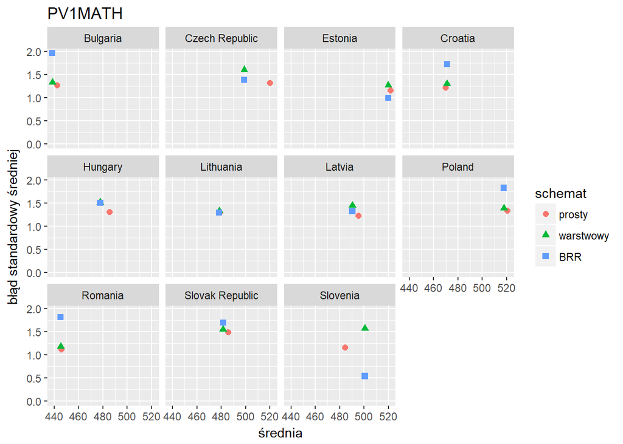

```r
srednie = rbind(
  cbind(srProsty, schemat = "prosty"),
  cbind(srWarst, schemat = "warstwowy"),
  cbind(srRep, schemat = "BRR")
)
ggplot(srednie, aes_string(zmienna, "se", shape = "schemat", colour = "schemat")) +
  geom_point(size = 2) +
  facet_wrap(~CNT) +
  scale_x_continuous(name = "średnia") +
  scale_y_continuous(name = "błąd standardowy średniej", limits = c(0, NA)) +
  ggtitle(zmienna)
```

```r
#View(srednie)
```

Jak widać w blisko połowie analizowanych krajów błędy standardowe oszacowane poprawnie, z wykorzystaniem metod replikacyjnych, okazują się zauważalnie większe, niż szacowane przy zastosowaniu standardowych (lecz nieadekwatnych) technik, tak jak dla doboru prostego. Jednak zdarzają się wyjątki - na Słowenii zastosowanie wag replikacyjnych prowadzi do zmniejszenia się szacowanej wielkości błędu standardowego o połowę (w porównaniu do szacowania jak dla doboru prostego).

```r
zmienna = "OUTHOURS"
(srProsty = svyby(make.formula(zmienna), ~CNT, student2012prosty, svymean, na.rm = TRUE))
```

```
##                             CNT  OUTHOURS        se
## Bulgaria               Bulgaria 12.356347 0.1846856
## Czech Republic   Czech Republic  6.584296 0.1019530
## Estonia                 Estonia 12.145420 0.1761742
## Croatia                 Croatia 10.805530 0.1562156
## Hungary                 Hungary 11.848514 0.1700354
## Lithuania             Lithuania 11.936213 0.1759904
## Latvia                   Latvia 13.128723 0.1900939
## Poland                   Poland 13.381015 0.1828705
## Romania                 Romania 12.853296 0.2022257
## Slovak Republic Slovak Republic  7.227076 0.1159047
## Slovenia               Slovenia  8.025573 0.1204763
```

```r
(srWarst = svyby(make.formula(zmienna), ~CNT, student2012warstw, svymean, na.rm = TRUE))
```

```
##                             CNT  OUTHOURS        se
## Bulgaria               Bulgaria 12.248249 0.1861103
## Czech Republic   Czech Republic  6.786245 0.1271545
## Estonia                 Estonia 12.073865 0.1836875
## Croatia                 Croatia 10.858944 0.1630804
## Hungary                 Hungary 11.704462 0.1875311
## Lithuania             Lithuania 11.972079 0.1774656
## Latvia                   Latvia 12.762954 0.2005477
## Poland                   Poland 13.410594 0.1903183
## Romania                 Romania 12.926519 0.2219164
## Slovak Republic Slovak Republic  7.214493 0.1228478
## Slovenia               Slovenia  8.220793 0.1997418
```

```r
(srRep = svyby(make.formula(zmienna), ~CNT, student2012rep, svymean, na.rm = TRUE))
```

```
##                             CNT  OUTHOURS         se
## Bulgaria               Bulgaria 12.248249 0.10920905
## Czech Republic   Czech Republic  6.786245 0.07996801
## Estonia                 Estonia 12.073865 0.09064933
## Croatia                 Croatia 10.858944 0.09367130
## Hungary                 Hungary 11.704462 0.11127528
## Lithuania             Lithuania 11.972079 0.08947766
## Latvia                   Latvia 12.762954 0.11372983
## Poland                   Poland 13.410594 0.11259267
## Romania                 Romania 12.926519 0.13974646
## Slovak Republic Slovak Republic  7.214493 0.08413585
## Slovenia               Slovenia  8.220793 0.10620610
```

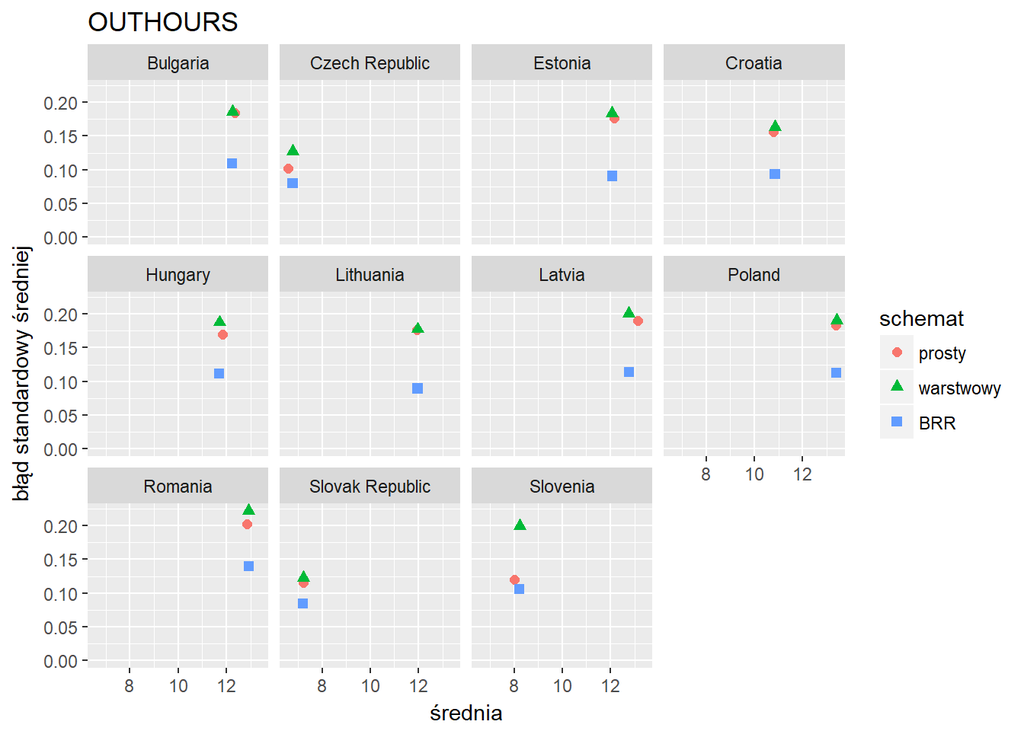

```r
srednie = rbind(
  cbind(srProsty, schemat = "prosty"),
  cbind(srWarst, schemat = "warstwowy"),
  cbind(srRep, schemat = "BRR")
)
ggplot(srednie, aes_string(zmienna, "se", shape = "schemat", colour = "schemat")) +
  geom_point(size = 2) +
  facet_wrap(~CNT) +
  scale_x_continuous(name = "średnia") +
  scale_y_continuous(name = "błąd standardowy średniej", limits = c(0, NA)) +
  ggtitle(zmienna)
```

```r
#View(srednie)
```

W przypadku zmiennej `OUTHOURS`, opisującej tygodniową liczbę godzin dodatkowej nauki poza szkołą, we wszystkich analizowanych krajach błędy standardowe szacowane metodą BRR są niższe niż szacowane tak, jak dla doboru prostego. Najwyraźniej uczniowie w ramach szkół bardzo różnią się ze względu tą cechę (podczas gdy średnie tej zmiennej na poziomie szkół różnią się od siebie niewiele).

## Sumy populacyjne

Widzieliśmy już, jak przy pomocy funkcji `svytable()` można estymować rozkład liczebności zmiennej w populacji (o ile definiując schemat doboru próby podaliśmy prawdopodobieństwa lub *sampling weights*). Dla zmiennej ciągłej możemy też wyestymować sumę wartości tej zmiennej w populacji. Np. łączną liczbę godzin nauki tygodniowo poza szkołą dla wszystkich *piętnastoletnich* uczniów danego kraju:

```r
svyby(~OUTHOURS, ~CNT, student2012rep, svytotal, na.rm = TRUE)
```

```
##                             CNT   OUTHOURS        se
## Bulgaria               Bulgaria  403929.32  5445.762
## Czech Republic   Czech Republic  353959.02  6336.575
## Estonia                 Estonia   92010.69  1148.877
## Croatia                 Croatia  325302.37  4646.637
## Hungary                 Hungary  692137.68 11741.897
## Lithuania             Lithuania  258008.58  2759.308
## Latvia                   Latvia  135421.29  2031.357
## Poland                   Poland 3349773.69 30573.141
## Romania                 Romania 1157275.26 15045.853
## Slovak Republic Slovak Republic  251519.08  4252.030
## Slovenia               Slovenia   98946.64  1535.275
```

# 3. Wizualizacja danych ze złożonych schematów doboru próby

## Funkcje pakietu survey

Funkcje graficzne pakietu *survey* działają w oparciu o *klasyczną* grafikę R - pakiet *graphics*. W związku z tym wszystkie argumenty sterujące wyglądem poszczególnych elementów wykresy są w ich przypadku identyczne, jak w analogicznych funkcjach pakietu *graphics*: `hist()`, `boxplot()` i `plot()`/`points()`. Utworzone wykresy mogą też być uzupełniane o dalsze elementy przy użyciu innych funkcji pakietu *graphics*.

### Histogramy

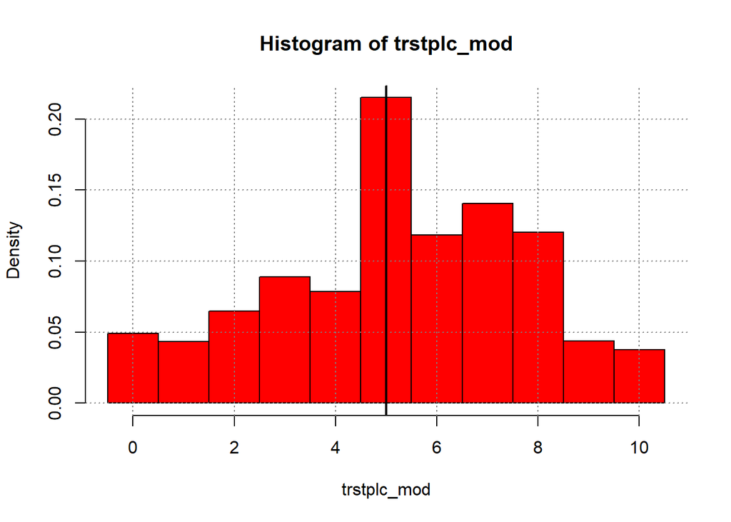

```r
svyhist(~trstplc_mod, ess2012Pl, breaks = seq(-0.5, 10.5, 1), col = "red")
grid(col = grey(0.5))
abline(v = 5, lwd = 2)
```

### Wykresy skrzynkowe

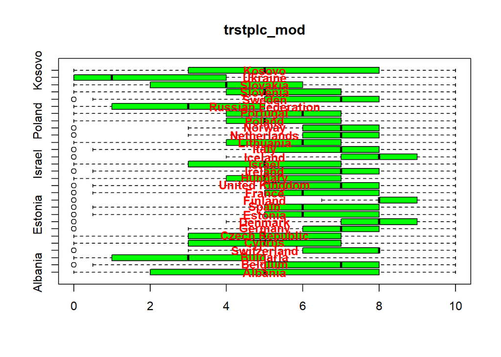

```r
svyboxplot(trstplc_mod ~ cntry, ess2012warstw, main = "trstplc_mod",
           col = "green", horizontal = TRUE)
text(5, 1:nlevels(ess2012warstw$variables$cntry),
     levels(ess2012warstw$variables$cntry), col = "red", font = 2)
```

### Wykresy rozrzutu

Funkcja `svyplot()`, w odróżnieniu od wcześniejszych, posiada więcej specyficznych dla siebie argumentów. Przede wszystkim argument `style` pozwala wybrać jeden ze sposobów reprezentowania danych na wykresie:

- `style = "bubble"` - poszczególne obserwacje reprezentowane są przez punkty, których wielkość jest proporcjonalna do wagi przypisanej danej obserwacji; bardzo ograniczona kontrola nad wyglądem punktów (właściwie tylko wybór koloru); użyteczne tylko przy niewielkiej liczbie obserwacji;
- `style = "transparent"` - poszczególne obserwacje reprezentowane są przez punkty, których przeźroczystość jest proporcjonalna do wagi przypisanej danej obserwacji; bardzo ograniczona kontrola nad wyglądem punktów (właściwie tylko wybór koloru); użyteczne tylko przy niewielkiej liczbie obserwacji;
- `style = "subsample"` - na wyresie nie są rysowane dane, jakie mamy w obiekcie ze schematem, lecz wygenerowana na ich podstawie *prosta próba z populacji*; większa swoboda decydowania o wyglądzie punktów, ale wciąż użyteczne tylko dla małych danych;
- `style = "hex"` i `style = "greyhex"` - wykres typu *mapa ciepła*, w którym powierzchnia dzielona jest równomiernie na obszary (tu: szcześciokąty foremne), których kolor odpowiada zagęszczeniu obserwacji (sumy wag) w granicach poszczególnych obszarów; do działania wymagają zainstalowania pakietu *hexbin*.

Należy też zwrócić uwagę, że pierwsza zmienna podawana w formule umieszczona zostanie na osi Y, a druga na osi X (tak, jakby specyfikować model regresji).

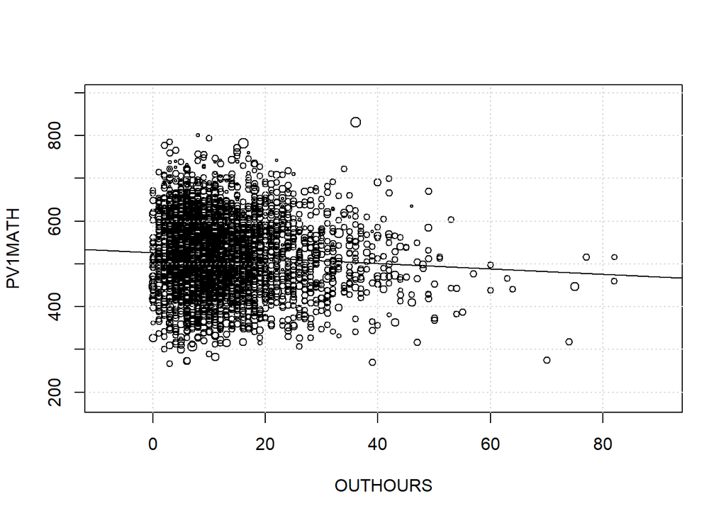

```r
svyplot(PV1MATH ~ OUTHOURS, subset(student2012rep, CNT == "Poland"),
        style = "bubble", xlab = "OUTHOURS", ylab = "PV1MATH")
grid()
abline(svyglm(PV1MATH ~ OUTHOURS,
              design = subset(student2012rep, CNT == "Poland")))
```

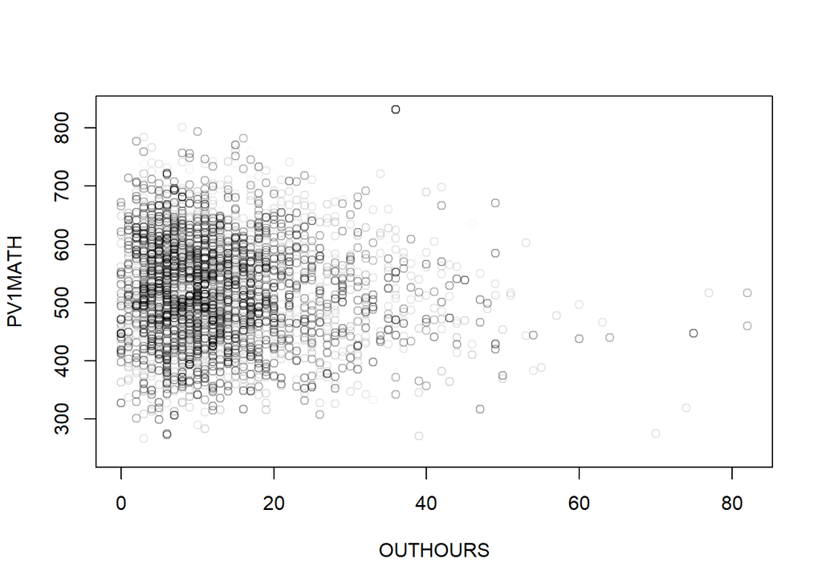

```r
svyplot(PV1MATH ~ OUTHOURS, subset(student2012rep, CNT == "Poland"),
        style = "transparent", xlab = "OUTHOURS", ylab = "PV1MATH")
```

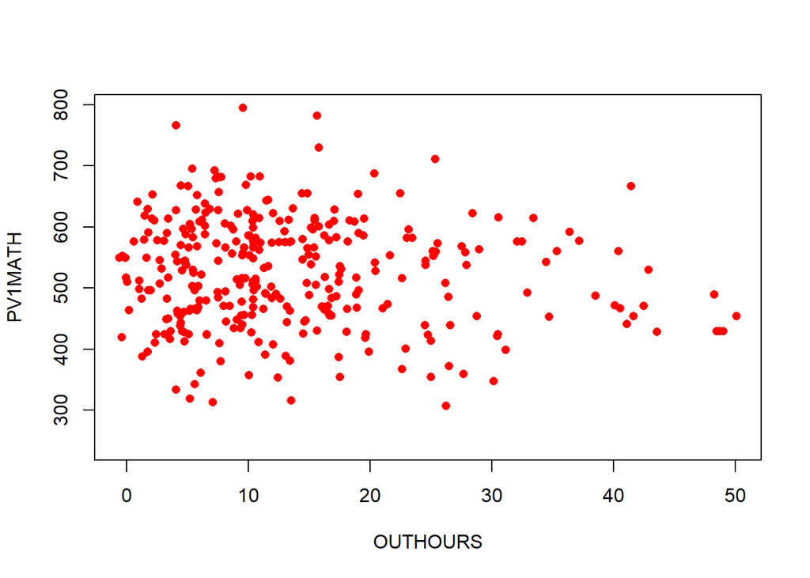

```r
svyplot(PV1MATH ~ OUTHOURS, subset(student2012rep, CNT == "Poland"),
        style = "subsample", xlab = "OUTHOURS", ylab = "PV1MATH",
        pch = 16, col = "red")
```

## Funkcje pakietu ggplot2

Obiektów zawierających opis schematu doboru próby nie możemy użyć wprost jako źródeł danych dla funkcji pakietu *ggplot2*, jednak ich element `variables` już jak najbardziej. Wywołując funkcje pakietu *ggplot2* (a nawet konkretnie funkcję `aes()`) będziemy musieli deklarować, że na potrzeby rysowania wykresu nie chcemy zliczać wierszy w danych, lecz sumować przypisane do nich wagi.

### Rozkład jednej zmiennej i rozkłady warunkowe

Funkcji `geom_bar()`, czy `geom_hist()` używamy dodając w wywołaniu `aes()` argument `weights`, któremu przypisujemy wartość wag. Oczywiście jeśli podamy tu *sampling weights*, na osi Y wykresu otrzymamy w efekcie szacowane liczebności populacyjne.

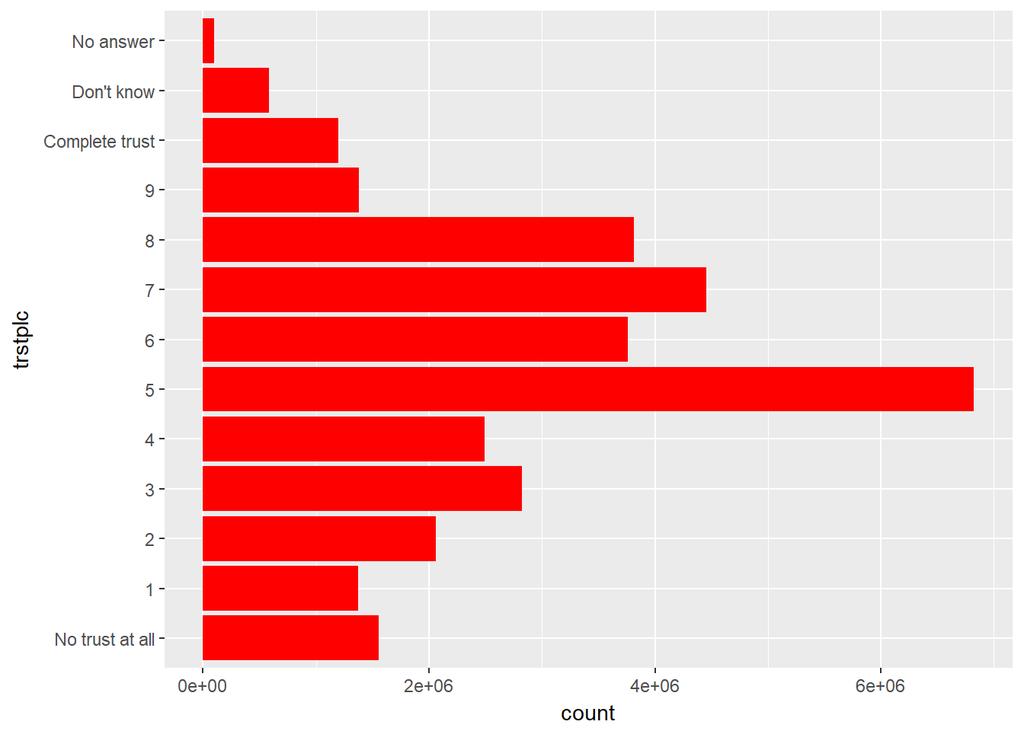

```r
ggplot(ess2012Pl$variables, aes(trstplc,
                                weight = 1 / (prob_psu * prob_ind))) +
  geom_bar(fill = "red") + coord_flip()
```

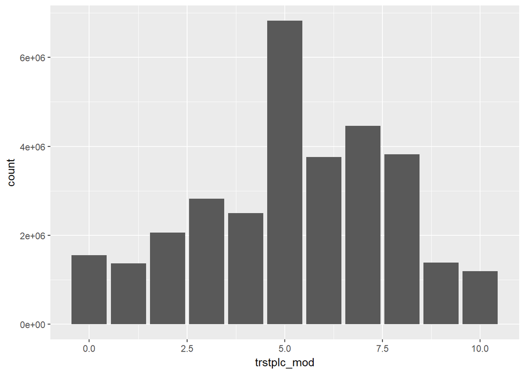

```r
ggplot(ess2012Pl$variables, aes(trstplc_mod,
                                weight = 1 / (prob_psu * prob_ind))) +
  geom_bar()
```

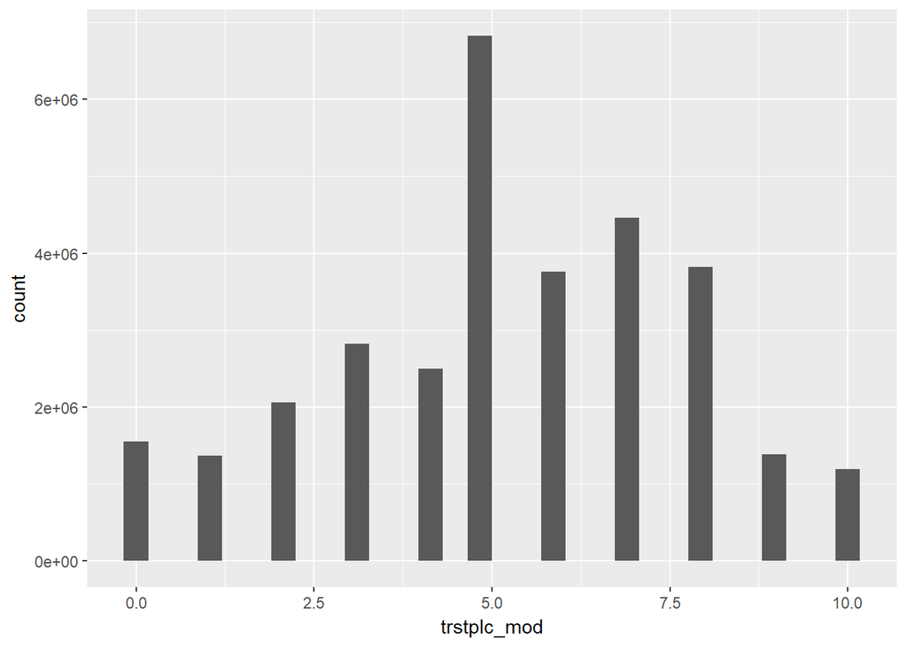

```r
ggplot(ess2012Pl$variables, aes(trstplc_mod,
                                weight = 1 / (prob_psu * prob_ind))) +
  geom_histogram()
```

Chcąc uzyskać rozkłady procentowe, musimy najpierw przygotować tabelę z rozkładem przy pomocy funkcji `svytable()`, przekształcić ją na pożądany rozkład częstości (lub rodzinę warunkowych rozkładów częstości) i dopiero podać jako argument do `ggplot()`.

```r
(tab = svytable(~trstplc + cntry, ess2012warstw))
```

```
##                  cntry
## trstplc               Albania     Belgium    Bulgaria Switzerland
##   No trust at all 218.6245012  41.0000000 475.2728482  20.0000000
##   1                48.4364562  34.0000000 179.2312718   6.0000000
##   2                88.3101134  52.0000000 212.3143184  20.0000000
##   3                80.3397608 110.0000000 258.6050720  36.0000000
##   4                73.3472043 117.0000000 254.3235412  56.0000000
##   5               185.8230974 272.0000000 300.5362286 131.0000000
##   6                71.9492698 237.0000000 126.7924561 152.0000000
##   7                99.9958290 505.0000000 101.8611509 317.0000000
##   8               105.8161529 351.0000000 105.3968043 385.0000000
##   9                52.2809071 110.0000000  53.8019421 233.0000000
##   Complete trust  172.1909161  37.0000000 104.0341737 129.0000000
##   Refusal           0.3865489   0.0000000   0.0000000   0.0000000
##   Don't know        3.4992429   3.0000000  86.3832324   8.0000000
##   No answer         0.0000000   0.0000000   1.4469602   0.0000000
##                  cntry
## trstplc                Cyprus Czech Republic     Germany     Denmark
##   No trust at all 112.2045454     98.9873770  36.2469208   8.0000000
##   1                65.3389258     81.2824024  18.3158447   4.0000000
##   2                63.2424355    151.8778992  55.0301814   7.0000000
##   3                91.7021821    176.6285032 109.9045575  24.0000000
##   4                85.9857474    256.7619871 157.4398620  32.0000000
##   5               202.9174300    359.3695483 305.4270825  88.0000000
##   6               129.4443505    172.3032537 311.6362805  83.0000000
##   7               135.0947266    239.9837783 560.1119562 224.0000000
##   8               117.2611195    222.0835314 775.0370661 474.0000000
##   9                41.7534386    148.6857119 370.6292990 439.0000000
##   Complete trust   58.4816821     49.0609538 251.2666462 261.0000000
##   Refusal           0.0000000      0.0000000   0.5405739   0.0000000
##   Don't know       11.3602396     30.6730514   6.4137291   6.0000000
##   No answer         1.2131768     21.3020022   0.0000000   0.0000000
##                  cntry
## trstplc               Estonia       Spain     Finland      France
##   No trust at all  94.0000000  96.8680969   5.0000000  62.9089592
##   1                59.0000000  26.7570673   6.0000000  34.7688132
##   2                98.0000000  61.7419159  14.0000000  68.6366029
##   3               171.0000000 126.6410246  19.0000000 121.5097125
##   4               143.0000000 135.9482808  42.0000000 139.4153325
##   5               421.0000000 323.0935276  73.0000000 322.3716760
```

[output cut: 73 more lines]

```
## trstplc                Kosovo
##   No trust at all 114.5144034
##   1                57.1379871
##   2                63.5862836
##   3                89.6516310
##   4                93.9235260
##   5               225.5666333
##   6                99.4891444
##   7               112.4905187
##   8               141.4267475
##   9                93.0569545
##   Complete trust  182.0884005
##   Refusal           0.0000000
##   Don't know       22.0677700
##   No answer         0.0000000
```

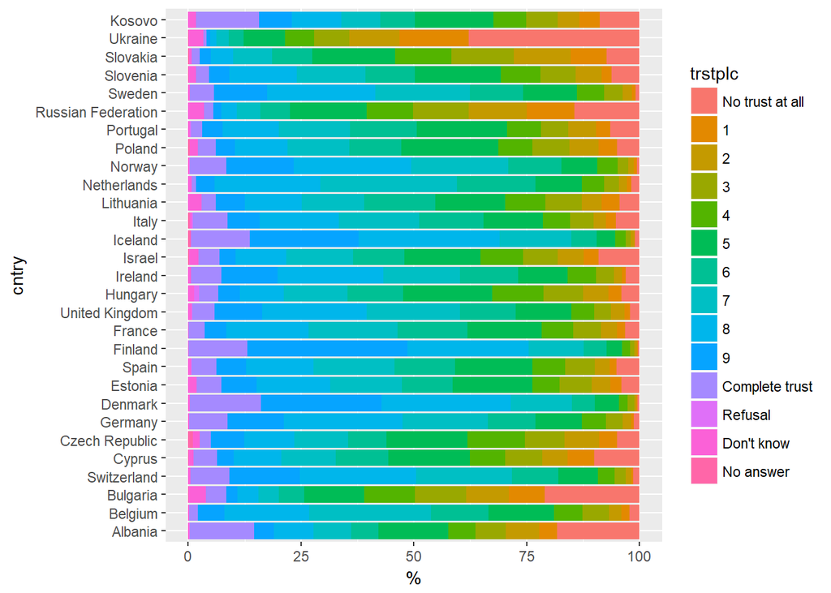

```r
ggplot(as.data.frame(100 * prop.table(tab, 2)),
       aes(cntry, fill = trstplc, weight = Freq)) +
  geom_bar() + ylab("%") + coord_flip()
```

Również wykorzystując funkcje `geom_boxplot()` lub `geom_violin()` korzystamy z argument `weights` w wywołaniu `aes()`.

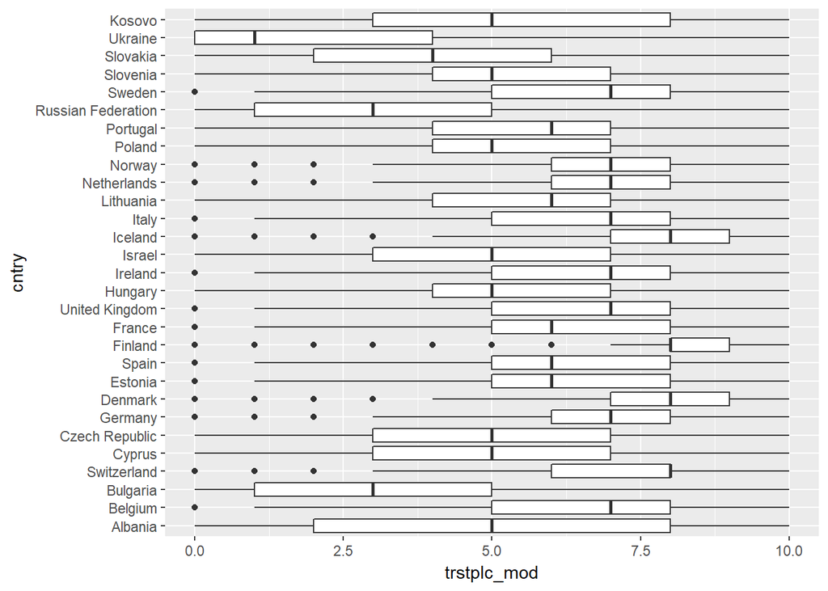

```r
ggplot(ess2012warstw$variables,
       aes(cntry, trstplc_mod, weight = dweight)) +
  geom_boxplot() + coord_flip()
```

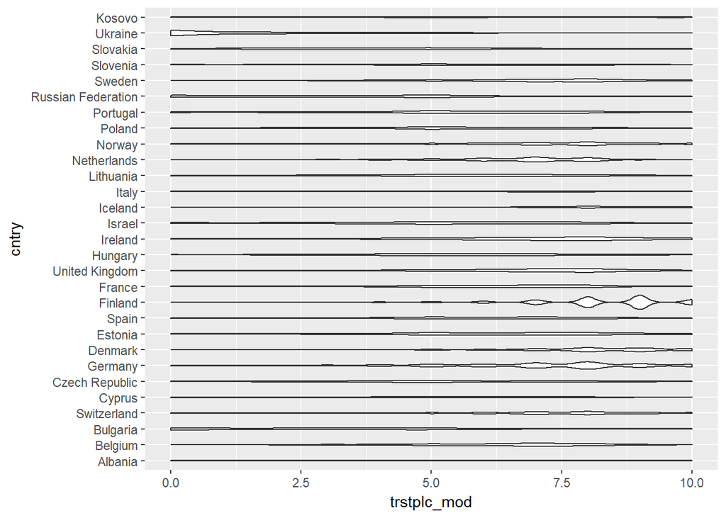

```r
ggplot(ess2012warstw$variables,
       aes(cntry, trstplc_mod, weight = dweight)) +
  geom_violin() + coord_flip()
```

### Wykresy rozrzutu

Wykorzystując `geom_point()` możemy na podstawie wag dobierać wielkość lub kolor punktów.

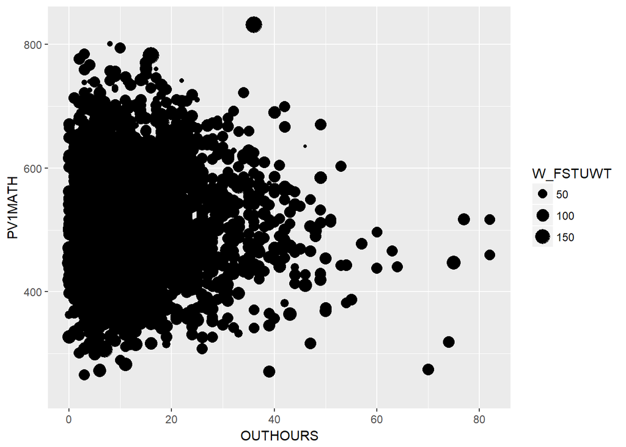

```r
ggplot(subset(student2012rep, CNT == "Poland")$variables,
       aes(OUTHOURS, PV1MATH, size = W_FSTUWT)) +
  geom_point()
```

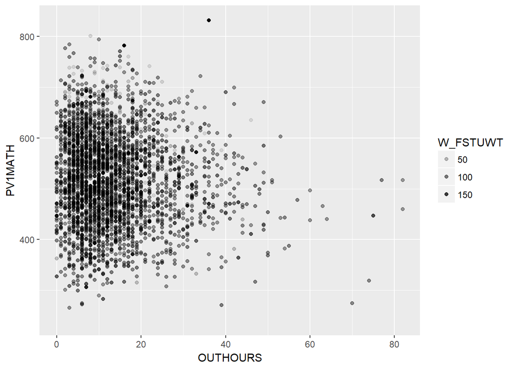

```r
ggplot(subset(student2012rep, CNT == "Poland")$variables,
       aes(OUTHOURS, PV1MATH, alpha = W_FSTUWT)) +
  geom_point()
```

Zwykle bardziej użytecznie będzie jednak skorzystać z wykresów typu *mapa ciepła*, znów posługując się argumentem `weight` w wywołaniu `aes()`.

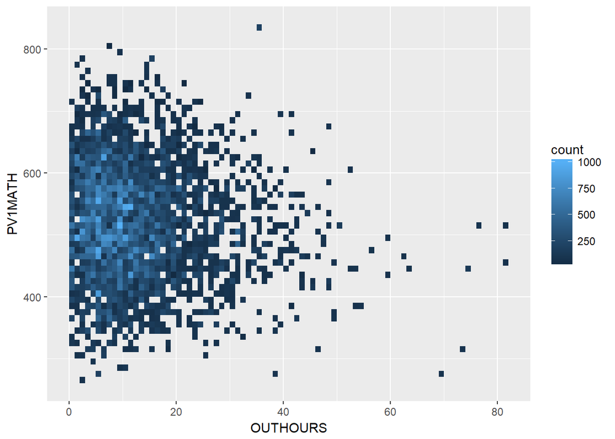

```r
ggplot(subset(student2012rep, CNT == "Poland")$variables,
       aes(OUTHOURS, PV1MATH, weight = W_FSTUWT)) +
  geom_bin2d(binwidth = c(1, 10))
```

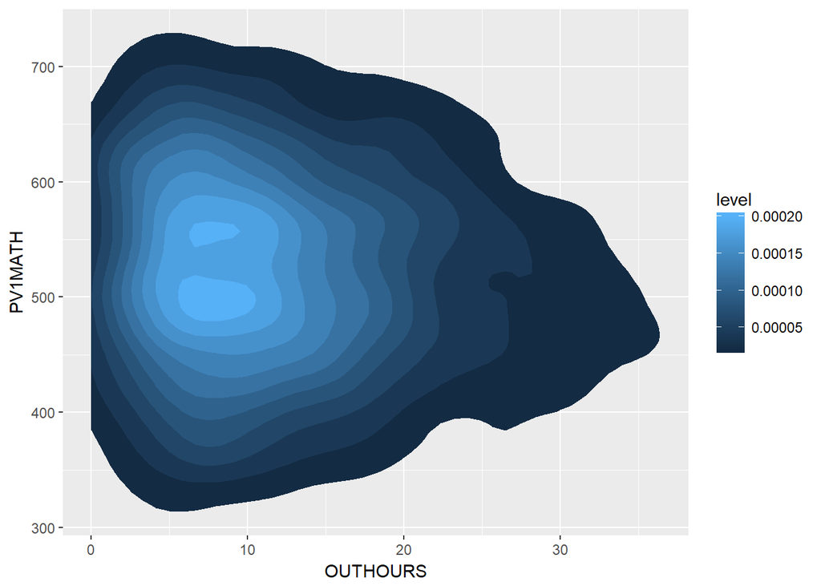

```r
ggplot(subset(student2012rep, CNT == "Poland")$variables,
       aes(OUTHOURS, PV1MATH, weight = W_FSTUWT)) +
  stat_density_2d(aes(fill = ..level..), geom = "polygon")
```

Możemy też w analogiczny sposób wykorzystać `geom_smooth()`, pamiętając jedynie, że zwrócone przez tę funkcję oszacowania błędów standardowych (a w konsekwencji *powierzchni ufności*) nie będą uwzględniać efektywności schematu doboru próby, więc lepiej powstrzymać się od wykorzysatania ich na wykresie.

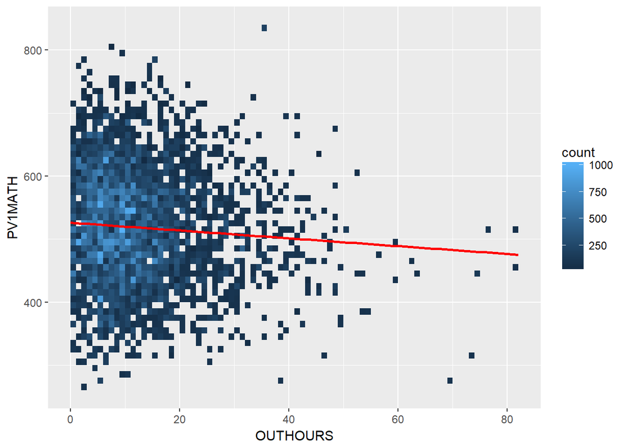

```r
ggplot(subset(student2012rep, CNT == "Poland")$variables,
       aes(OUTHOURS, PV1MATH, weight = W_FSTUWT)) +
  geom_bin2d(binwidth = c(1, 10)) +
  geom_smooth(method = "lm", colour = "red", se = FALSE)
```

# 4. Analizy regresji (uogólniony model liniowy)

## Kontekst i kilka ogólnych wniosków

Tradycyjnie, w badaniach wykorzystujących w pełny sposób wnioskowanie statystyczne uwzględniające złożony schemat doboru próby badawczej, przedmiotem zainteresowania były parametry populacyjne rozkładów poszczególnych zmiennych, a nie zależności między zmiennymi. Zależnościami takimi interesowano się, ale w dosyć specyficznym kontekście - jako czymś dającym możliwość bardziej precyzyjnego wnioskowania o parametrach populacyjnych jednych zmiennych, jeśli wziąć pod uwagę dostępne informacje o wartościach innych zmiennych, które są z nimi powiązane. W związku z tym w literaturze poświęconej analizie danych z uwzględnienim złożonych schematów doboru próby regresja wprowadzana jest zwykle w kontekście estymatorów regresyjnych sum populacyjnych, a nie jako sposób badania związków pomiędzy zmiennymi.

Przystępując do analizy regresji w celu badania związków między zmiennymi z wykorzystaniem danych z prób dobranych w sposób złożony należy zdawać sobie sprawę, że złożony schemat doboru próby może wpływać na prowadzone analizy regresji na dwa sposoby:

1. Poprzez róźnicę efektywności związaną z wykorzystaniem schematu zespołowego lub wielostopniowego oraz warstwowania.
2. Poprzez nierówne prawdopodobieństwa wyboru jednostek do próby - a więc i nieróWne wagi.

Pierwszy aspekt powinien zostać uwzględniony poprzez wykorzystanie tzw. estymatorów *sandwich* (które mogą być postrzegane jako rodzaj linearyzacji Taylora), w formie adekwatnej do zastosowanego schematu, lub metod replikacyjnych do szacowania wielkości błędów standardowych.

Drugi aspekt wymaga nieco dokładniejszego rozważenia.

- Zauważmy, że jeżeli chcemy interpretować model regresji w sposób przyczynowy, to jego parametry nie powinny zależeć od rozkładów brzegowych analizowanych zmiennych (tzn. jeśli model jest *prawdziwy*, to zmiana wartości predyktora w danej zbiorowości powinna wpływać na odpowiednią zmianę rozkładu zmiennej zależnej).
  - Ponieważ zastosowanie (lub nie) ważenia interpretuje się właśnie w kategoriach dostosowania przewidywanego poziomu (rozkładu) analizowanych zmiennych, nie powinno ono wpływać na szacowane parametry modelu regresji.
  - Chyba że model regresji cierpi na problem pominiętych predyktorów (i nie może być interpretowany w sposób przyczynowy).

Wynikają z tego dwa wnioski:

1) Uwzględnienie ważenia w modelowaniu regresji w pierwszej kolejności odgrywa rolę *robustness check*. - Jeśli po uwzględnieniu ważenia nic poważnego się w modelu nie zmienia, jest to pośrednia **przesłanka** na rzecz tego, że jest on dobrze wyspecyfikowany. - Jeśli się zmienia, to znaczy, że należy rozważyć uzupełnienie go o dodatkowe predyktory (a przynajmniej należałoby się zastanowić, jak chcemy interpretować jego wyniki). 2) Uwzględnienie ważenia ma podobny wpływ na parametry modelu regresji, co włączenie do modelu jako dodatkowych predyktorów zmiennych, na podstawie których ustalana jest wartość wag (prawdopodobieństw wyboru do próby). - W związku z tym, gdy obserwujemy, że ważenie zmienia parametry modelu, warto rozważyć włączenie do modelu regresji właśnie zmiennych, z którymi powiązane są wagi. Pozwala to opisać ich oddziaływanie w sposób bardziej przejrzysty.

## Funkcja svyglm()

Funkcji `svyglm()` używa się w sposób analogiczny do `glm()`, z tym że zamiast argumentu `data` występuje tu argument `design`. Można przy jej pomocy estymować modele ściśle liniowe, logitowe, probitowe i Poissona.

Pakiet *survey* **nie** zapewnia za to narzędzi do estymacji:

- Modelu dla ujemnego rozkładu dwumianowego.
- Modeli mieszanych efektów.

```r
m1 = svyglm(PV1MATH ~ OUTHOURS, design = subset(student2012rep, CNT == "Poland"))
summary(m1)
```

```
##
## Call:
## svyglm(formula = PV1MATH ~ OUTHOURS, design = subset(student2012rep,
##     CNT == "Poland"))
##
## Survey design:
## subset(student2012rep, CNT == "Poland")
##
## Coefficients:
##              Estimate Std. Error t value Pr(>|t|)
## (Intercept) 526.21675    2.05149 256.505  < 2e-16 ***
## OUTHOURS     -0.62129    0.07385  -8.413 1.49e-12 ***
## ---
## Signif. codes:  0 '***' 0.001 '**' 0.01 '*' 0.05 '.' 0.1 ' ' 1
##
## (Dispersion parameter for gaussian family taken to be 5225.998)
##
## Number of Fisher Scoring iterations: 2
```

Obiekty zwracane przez funkcję `svyglm()` w wielu kontekstach zachowują się jak typowe modele będące efektem wywołwania funkcji `glm()` lub `lm()`. W szczególności:

- Posiadają zdefiniowane metody `summary()`, `coef()`, `predict()`, `vcov()`, które działają tak samo, jak dla bardziej typowych modeli regresji.
- Współpracują z funkcjami z pakietu *car*.
- Współpracują (od niedawna) z funkcjami pakietu *effects*.
- Współpracują z funkcjami `tidy()` i `augument()` z pakietu *broom*.

Dotyczą ich jednak również pewne ograniczenia:

- Jako estymowane w oparciu o pseudowiarygodność nie mają zdefiniowanej metody `anova()`.
  - W pakietem *survey* mamy jednak funkcję `regTermTest()`, która pozwala wygodnie testować hipotezy o istotności uwzględnienia w modelu czynników. W tym samym celu można też użyć funkcji `Anova()` z pakietu *car*.
- Z analogicznych powodów nie jest dla nich zwracane R-kwadrat, ani wartość BIC. Nieco inaczej jest też raportowany AIC.
  - Z tego powodu nie działa w odniesieniu do nich funkcja `glance()` z pakietu *broom*.
  - Warto przeczytać: T. Lumley & A. Scott. 2015. AIC and BIC for Modeling with Complex Survey Data. *Journal of Survey Statistics and Methodology* 3(1), 1-18.
- Metoda `plot()` jest dostępna, ale zróżnicowanie wag nie jest reprezentowane na wykresach rozrzutu; zupełnie nie jest też brane pod uwagę przy wykresie *kwantyl-kwantyl* (zresztą ten ostatni element diagnostyki jest przy nierównych wagach kłopotliwy formalnie).

**Czy nasz model jest wrażliwy na użycie schematu?**

```r
m1p = svyglm(PV1MATH ~ OUTHOURS, design = subset(student2012prosty, CNT == "Poland"))
summary(m1)$coef
```

```
##                Estimate Std. Error    t value      Pr(>|t|)
## (Intercept) 526.2167515  2.0514873 256.505002 6.559914e-116
## OUTHOURS     -0.6212857  0.0738489  -8.412931  1.488589e-12
```

```r
summary(m1p)$coef
```

```
##                Estimate Std. Error    t value    Pr(>|t|)
## (Intercept) 530.3481856  2.7466305 193.090472 0.00000e+00
## OUTHOURS     -0.6822262  0.1578139  -4.322978 1.58894e-05
```

Jeśli chodzi o wartość parametru nachylenia, to różnice są znikome. Różnicą w wartości stałej regresji możemy się nie przejmować (zresztą i tak nie jest zbyt duża). Znaczne są za to różnice wielkości błędów standardowych, przy czym wykorzystanie informacji o schemacie doboru pozwala akurat je zredukować.

### Trochę bogatszy model regresji

Zbadajmy przebieg związków pomiędzy intensywnością pozaszkolnych zajęć związanych z nauką a wynikami testu z matematyki w podziale na płeć (`ST04Q01`) i poszczególne kraje.

```r
m2 = svyglm(PV1MATH ~ OUTHOURS * ST04Q01 * CNT, design = student2012rep)
summary(m2)
```

```
##
## Call:
## svyglm(formula = PV1MATH ~ OUTHOURS * ST04Q01 * CNT, design = student2012rep)
##
## Survey design:
## svrepdesign.default(repweights = "^W_FSTR", weights = ~W_FSTUWT,
##     type = "BRR", rho = 0.5, combined.weights = TRUE, data = student2012)
##
## Coefficients:
##                                          Estimate Std. Error t value
## (Intercept)                             424.58829    2.30103 184.521
## OUTHOURS                                  1.69197    0.13436  12.593
## ST04Q01Male                              12.72202    3.02303   4.208
## CNTCzech Republic                        79.59956    3.63778  21.881
## CNTEstonia                              103.87031    3.46627  29.966
## CNTCroatia                               37.69230    3.43774  10.964
## CNTHungary                               31.45604    3.76715   8.350
## CNTLithuania                             53.97480    3.34166  16.152
## CNTLatvia                                74.87218    3.41140  21.948
## CNTPoland                                95.19689    3.26171  29.186
## CNTRomania                               -2.63731    3.45164  -0.764
## CNTSlovak Republic                       64.56268    4.17327  15.471
## CNTSlovenia                              79.76817    3.09807  25.748
## OUTHOURS:ST04Q01Male                     -0.87738    0.20325  -4.317
## OUTHOURS:CNTCzech Republic               -2.33036    0.27396  -8.506
## OUTHOURS:CNTEstonia                      -2.34075    0.17863 -13.104
## OUTHOURS:CNTCroatia                      -1.44632    0.18936  -7.638
## OUTHOURS:CNTHungary                      -0.15453    0.19065  -0.811
## OUTHOURS:CNTLithuania                    -1.60814    0.18701  -8.599
## OUTHOURS:CNTLatvia                       -1.94532    0.17767 -10.949
## OUTHOURS:CNTPoland                       -1.72491    0.16724 -10.314
## OUTHOURS:CNTRomania                       0.20704    0.16960   1.221
## OUTHOURS:CNTSlovak Republic              -2.51800    0.32056  -7.855
## OUTHOURS:CNTSlovenia                     -2.23052    0.23969  -9.306
## ST04Q01Male:CNTCzech Republic             3.91898    4.89607   0.800
## ST04Q01Male:CNTEstonia                   -3.84125    3.92479  -0.979
## ST04Q01Male:CNTCroatia                    2.46460    4.12801   0.597
## ST04Q01Male:CNTHungary                   10.93507    5.27907   2.071
## ST04Q01Male:CNTLithuania                 -3.21386    3.81451  -0.843
## ST04Q01Male:CNTLatvia                   -15.70355    4.79233  -3.277
```

[output cut: 50 more lines]

```
## OUTHOURS:ST04Q01Male:CNTEstonia         0.461596
## OUTHOURS:ST04Q01Male:CNTCroatia         0.012837 *
## OUTHOURS:ST04Q01Male:CNTHungary         0.854842
## OUTHOURS:ST04Q01Male:CNTLithuania       0.855182
## OUTHOURS:ST04Q01Male:CNTLatvia          0.089575 .
## OUTHOURS:ST04Q01Male:CNTPoland          0.106702
## OUTHOURS:ST04Q01Male:CNTRomania         0.144710
## OUTHOURS:ST04Q01Male:CNTSlovak Republic 0.485895
## OUTHOURS:ST04Q01Male:CNTSlovenia        0.313971
## ---
## Signif. codes:  0 '***' 0.001 '**' 0.01 '*' 0.05 '.' 0.1 ' ' 1
##
## (Dispersion parameter for gaussian family taken to be 5004.742)
##
## Number of Fisher Scoring iterations: 2
```

Żeby zobrazować wyniki, użytecznie będzie posłużyć się pakietem *effects*.

```r
library(effects)
```

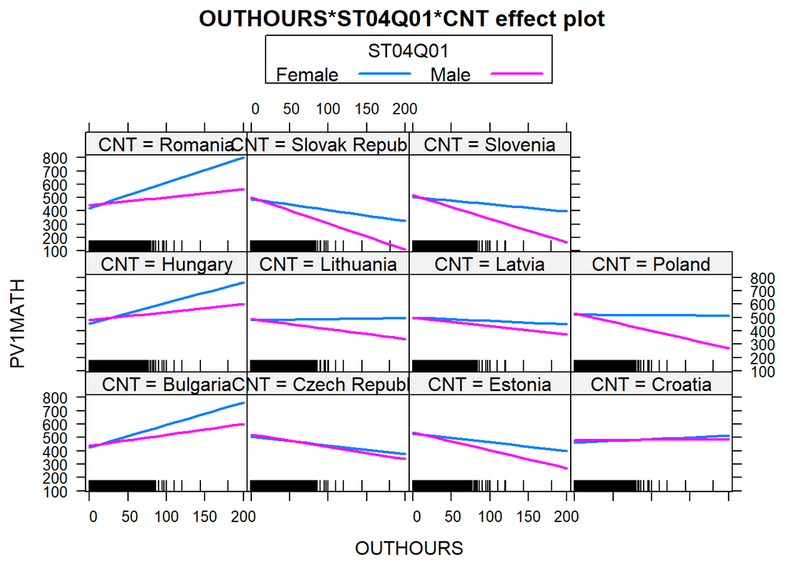

```r
plot(Effect(c("OUTHOURS", "ST04Q01", "CNT"), m2),
     x.var = "OUTHOURS", multiline = TRUE)
```

Czy mamy podstawy by twierdzić, że różnice wartości współczynników nachylenia związanych ze zmienną `OUTHOURS` między płciami nie są w analizowanych krajach takie same?

```r
regTermTest(m2, ~OUTHOURS:ST04Q01+OUTHOURS:ST04Q01:CNT)
```

```
## Wald test for OUTHOURS:ST04Q01 OUTHOURS:ST04Q01:CNT
##  in svyglm(formula = PV1MATH ~ OUTHOURS * ST04Q01 * CNT, design = student2012rep)
## F =  30.01095  on  11  and  36  df: p= 7.6083e-15
```

## A co z korelacją?

W pakiecie *survey* punktowe oszacowanie korelacji możemy obliczyć korzystając z faktu, że jako taką możemy interpretować wartość standaryzowanego współczynnika w regresji (z jedną zmienną niezależną).

```r
# niestety nie możemy wystandaryzować w ramach formuły, korzystając z funkcji scale()
# tylko musimy zrobić to "na piechotę"
designTemp =
  subset(student2012rep, CNT == "Poland" & !is.na(PV1MATH) & !is.na(OUTHOURS))
designTemp =
  update(designTemp,
         PV1MATH = (PV1MATH - svymean(~PV1MATH, designTemp)) /
           svyvar(~PV1MATH, designTemp)[1, 1]^0.5,
         OUTHOURS = (OUTHOURS - svymean(~OUTHOURS, designTemp)) /
           svyvar(~OUTHOURS, designTemp)[1, 1]^0.5)
# można liczyć
mKor1 = svyglm(PV1MATH ~ 0 + OUTHOURS, design = designTemp)
mKor2 = svyglm(OUTHOURS ~ 0 + PV1MATH, design = designTemp)
summary(mKor1)$coef
```

```
##             Estimate Std. Error   t value    Pr(>|t|)
## OUTHOURS -0.07040128 0.00832742 -8.454153 1.13334e-12
```

```r
summary(mKor2)$coef
```

```
##            Estimate  Std. Error   t value     Pr(>|t|)
## PV1MATH -0.07040128 0.009073356 -7.759123 2.564585e-11
```

```r
rm(mKor1, mKor2, designTemp)
```

Oszacowania punktowe z obu modeli są takie same, ale błąd standardowy i istotność już nie! Przy złożonym schemacie doboru zależą one bowiem od związków, z charakterystykami schematu: siły związku zmiennej zależnej ze zmienną opisującą wagi oraz stopnia, w jakim zmienna zależna *grupuje* się w ramach zespołów (jednostek losowania I stopnia).

W związku z tym przy analizach prowadzonych z wykorzystaniem danych z prób dobranych w sposób złożony generalnie unika się obliczania korelacji.

# 5. Poststratyfikacja

Poststratyfikacja (w szerokim rozumieniu tego terminu) to zestaw technik statystycznych mających na celu taką zmianę wag przypisywanych poszczególnym obserwacjom w próbie, aby dopasować wartości wybranych parametróW pewnych zmiennych estymowane na podstawie tej próby do znanych wartości populacyjnych. Zaliczane tu metody to:

- *Klasyczna* poststratyfikacja dla zmiennych kategorialnych oparta na uzgadnianiu całego rozkładu zmiennej (lub łącznego rozkładu kilku zmiennych).
- Ważenie wieńcowe (*raking*) - bardziej elastyczna wersja *klasycznej* poststratyfikacji, ułatwiająca jednoczesne uwzględnienie w procedurze kilku zmiennych.
- Kalibracja (*calibration*), w ramach której można dążyć do dopasowania do znanych wartości dowolnie zdefiniowanych parametrów, również dla zmiennych ciągłych (w szczególności średnich lub sum populacyjnych).

Poststratyfikacja dosyć powszechnie postrzegana jest jako remedium na problem nierównomiernej realizacji prób badawczych (np. respondenci o pewnych charakterystykach: młodsi, lepiej wykształceni, mieszkańcy dużych miast, są mniej skłonni do wyrażania zgody na udzielenie wywiadu), jednak w praktyce jest to w dużej mierze myślenie życzeniowe.

1. W praktyce typowo jesteśmy w stanie wykorzystać w postsratyfikacji tylko bardzo wąski zakres zmiennych *demograficznych*: płeć, wiek, region zamieszkania, które ze zmiennymi, które nas interesują (w analizie) są często w dosyć luźnych związkach.
2. Zastosowanie poststratyfikacji co prawda może wpłynąć na redukację obciążenia estymatorów (jeśli zmienne wykorzystane w poststratyfikacji są skorelowane z prawdopodobieństwem odmowy udziału w badaniu), jednak równocześnie wpływa również na wariancję tych estymatorów - i wpływ ten może być negatywny.
   - Zastosowanie poststratyfikacji zwykle zwiększa zróżnicowanie wartości wagprzypisanych obserwacjom i w ten sposób zwiększa wariancję estymatoróW.
   - Na rzecz zmniejszenia wariancji estymatorów będzie jednak oddziaływało, jeśli wagi po poststratyikacji są silniej (pozytywnie) związane z wartościami zmiennej, którą chcemy analizować, niż były przed posstratyfikacją. Dla wielu zmiennych taki pozytywny efekt jest jednak znikomy i nie równoważy zwiększenia wariancji estymatora w wyniku większego zróżnicowania wag.
   - Jeśli mamy dwa estymatory, z których jeden jest mniej obciążony, ale ma większą wariancję, a drugi jest bardziej obciążony, ale ma mniejszą wariancję, trudno powiedzieć, który z nich jest *lepszy* (można by szacować ich błąd średniokwadratowy, ale tego na podstawie pojedynczej próby nie jesteśmy w stanie zrobić).
3. Typowy sposób wykorzystania poststratyfikacji w badaniach społecznych pomija analizowanie wpływu jej zastosowania na wariancję estymatorów.
   - Nie wystarczy po prostu użyć wag poststratyikacyjnych zamiast *sampling weights* lub *wag analitycznych*.

## Postsratyfikacja w pakiecie *survey*

Pakiet *survey* umożliwia przeprowadzenie zarówno *klasycznej* poststratyfikacji (`postStratify()`), ważenia wieńcowego (`rake()`), jak i kalibracji (`calibrate()`). Niestety w praktyce często nie jest to zbyt wygodne. Np. w badaniu ESS poststratyfikację trzeba przeprowadzić dla każdego kraju oddzielnie - zestawy zmiennych wykorzystanych do poststratyfikacji różnią się między niektórymi krajami. W praktyce uniemożliwia to późniejsze posługiwanie się obiektem obejmującym wyniki z wszystkich krajów jednocześnie.

**Przeprowadźmy poststratyfikację dla Polski.**

Do poststratyfikacji polskiej próby z badania ESS 2012 zastosujemy metodę wag wieńcowych (*raking*), w ramach której wykorzystywane są dwie zmienne: `demogr` opisująca liczebność kategorii wiekowych i `regionR` opisujaca liczbę ludności mieszkającejw poszczególnych regionach.

Zacznijmy od wczytania zbioru danych z tymi zmiennymi i dołączenia ich do zbioru z wynikami ESS 2012 w Polsce.

```r
danePoststrat = read.csv2("dane/ESS6PL_zm_poststrat.csv")
danePoststrat$cntry = factor(danePoststrat$cntry, levels = levels(ess2012$cntry))
ess2012PlDane = merge(subset(ess2012, cntry == "Poland"), danePoststrat)
summary(ess2012PlDane[, c("demogr", "regionR")])
```

```
##      demogr         regionR
##  Min.   :11.00   Min.   :11.00
##  1st Qu.:12.00   1st Qu.:21.00
##  Median :21.00   Median :32.00
##  Mean   :17.24   Mean   :33.23
##  3rd Qu.:22.00   3rd Qu.:43.00
##  Max.   :23.00   Max.   :63.00
```

Następnie musimy zdefiniować ramki danych zawierające rozkłady populacyjne tych zmiennych.

```r
(PL2012demogr = setNames(as.data.frame(matrix(c(
  11, 278.304087435086,
  12, 260.726261173464,
  13, 281.731322784886,
  21, 265.001935768819,
  22, 260.790488015623,
  23, 404.445904822121
), ncol = 2, byrow = TRUE)), c("demogr", "Freq")))
```

```
##   demogr     Freq
## 1     11 278.3041
## 2     12 260.7263
## 3     13 281.7313
## 4     21 265.0019
## 5     22 260.7905
## 6     23 404.4459
```

```r
(PL2012regionR = setNames(as.data.frame(matrix(c(
  11, 146.27576768455,
  12, 271.471246522951,
  21, 161.204848783597,
  22, 238.24816668013,
  31, 115.760280482555,
  32, 101.095691362023,
  33,  72.7490479027425,
  34,  56.3166309146778,
  41, 158.085521170637,
  42,  73.963564946446,
  43,  50.4211591795123,
  51, 139.876942324461,
  52,  45.0279285484576,
  61,  96.6084936295843,
  62,  66.9178577447834,
  63, 103.976852122893
), ncol = 2, byrow = TRUE)), c("regionR", "Freq")))
```

```
##    regionR      Freq
## 1       11 146.27577
## 2       12 271.47125
## 3       21 161.20485
## 4       22 238.24817
## 5       31 115.76028
## 6       32 101.09569
## 7       33  72.74905
## 8       34  56.31663
## 9       41 158.08552
## 10      42  73.96356
## 11      43  50.42116
## 12      51 139.87694
## 13      52  45.02793
## 14      61  96.60849
## 15      62  66.91786
## 16      63 103.97685
```

Teraz definiujemy obiekt ze schematem doboru próby - tu zastosujemy powszechnie stosowane w socjologii podejście uproszczone, w którym jedynie używamy zmiennej `dweight` jako substytytu *wagi analitycznej* (definiując obiekt zeschematem w pakiecie survey - jako substytut *sampling weights*).

```r
(ess2012dweightPl = svydesign(ids = ~1, weights = ~dweight, data = ess2012PlDane))
```

```
## Independent Sampling design (with replacement)
## svydesign(ids = ~1, weights = ~dweight, data = ess2012PlDane)
```

Na obiekcie ze zdefinowanym schematem możemy przeprowadzić poststratyfikację.

```r
(ess2012poststratPl = rake(ess2012dweightPl,
                           sample.margins = list(~demogr, ~regionR),
                           population.margins = list(PL2012demogr, PL2012regionR)))
```

```
## Independent Sampling design (with replacement)
## rake(ess2012dweightPl, sample.margins = list(~demogr, ~regionR),
##     population.margins = list(PL2012demogr, PL2012regionR))
```

```r
str(ess2012poststratPl$postStrata)
```

```
## List of 1
##  $ :List of 2
##   ..$ : atomic [1:1898] 4 3 6 4 5 2 3 2 6 5 ...
##   .. ..- attr(*, "oldweights")= Named num [1:1898] 0.992 0.947 1.114 0.857 1.202 ...
##   .. .. ..- attr(*, "names")= chr [1:1898] "1" "2" "3" "4" ...
##   .. ..- attr(*, "weights")= Named num [1:1898] 0.913 0.877 1.028 0.789 1.121 ...
##   .. .. ..- attr(*, "names")= chr [1:1898] "1" "2" "3" "4" ...
##   ..$ : atomic [1:1898] 3 15 4 12 12 16 4 4 2 6 ...
##   .. ..- attr(*, "oldweights")= Named num [1:1898] 0.913 0.877 1.028 0.789 1.121 ...
##   .. .. ..- attr(*, "names")= chr [1:1898] "1" "2" "3" "4" ...
##   .. ..- attr(*, "weights")= Named num [1:1898] 0.99 0.95 1.114 0.856 1.216 ...
##   .. .. ..- attr(*, "names")= chr [1:1898] "1" "2" "3" "4" ...
##   ..- attr(*, "class")= chr "raking"
```

Zauważmy, że w obiekcie po przeprowadzeniu poststratyfikacji przechowywane są zarówno stare, jak i nowe wagi - jest to konieczne do szacowania wpływu poststratyfikacji na wariancję estymatorów.

Utwórzmy też obiekt zawierający schemat z *naiwną* poststratyfikacją, tzn. wykorzystujący wagi postsratyfikacyjne po prostu w roli *wag analitycznych*.

```r
(ess2012npoststratPl = svydesign(ids = ~1, weights = ~wps,
                                 data = cbind(ess2012PlDane,
                                              wps = weights(ess2012poststratPl))))
```

```
## Independent Sampling design (with replacement)
## svydesign(ids = ~1, weights = ~wps, data = cbind(ess2012PlDane,
##     wps = weights(ess2012poststratPl)))
```

Teraz możemy coś przeanalizować…

```r
(zmienne = grep("^trst.*_mod", names(ess2012), value = TRUE))
```

```
## [1] "trstprl_mod" "trstlgl_mod" "trstplc_mod" "trstplt_mod" "trstprt_mod"
## [6] "trstep_mod"  "trstun_mod"
```

```r
svymean(make.formula(zmienne), ess2012dweightPl, na.rm = TRUE)
```

```
##               mean     SE
## trstprl_mod 2.9448 0.0596
## trstlgl_mod 3.6618 0.0613
## trstplc_mod 5.1675 0.0658
## trstplt_mod 2.2883 0.0531
## trstprt_mod 2.2931 0.0527
## trstep_mod  4.2192 0.0645
## trstun_mod  5.0269 0.0667
```

```r
svymean(make.formula(zmienne), ess2012poststratPl, na.rm = TRUE)
```

```
##               mean     SE
## trstprl_mod 2.9430 0.0593
## trstlgl_mod 3.6398 0.0601
## trstplc_mod 5.1655 0.0656
## trstplt_mod 2.2926 0.0535
## trstprt_mod 2.2964 0.0528
## trstep_mod  4.2209 0.0640
## trstun_mod  5.0197 0.0660
```

```r
svymean(make.formula(zmienne), ess2012npoststratPl, na.rm = TRUE)
```

```
##               mean     SE
## trstprl_mod 2.9430 0.0600
## trstlgl_mod 3.6398 0.0616
## trstplc_mod 5.1655 0.0661
## trstplt_mod 2.2926 0.0540
## trstprt_mod 2.2964 0.0534
## trstep_mod  4.2209 0.0649
## trstun_mod  5.0197 0.0668
```

…ale jak widać wyniki niemal się od siebie nie różnią.

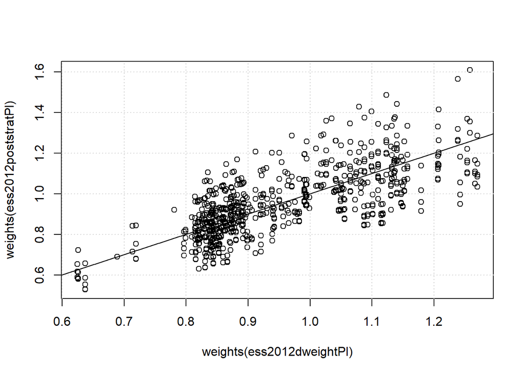

```r
plot(weights(ess2012dweightPl), weights(ess2012poststratPl))
grid()
abline(0, 1)
```

```r
cor(weights(ess2012dweightPl), weights(ess2012poststratPl))
```

```
## [1] 0.7347829
```

W dużej mierze bierze się to z faktu, że wagi wynikajće ze schematu doboru i wagi poststratyfikacyjne po prostu niezbyt się od siebie różnią (co z koleiwynika z tego, że badanie ESS jest w Polsce bardzo porządnie - i w efekcie dosyć *równomiernie* - realizowane).

```r
round(cor(ess2012PlDane[, zmienne],
          cbind(dweight = weights(ess2012dweightPl),
                poststrat = weights(ess2012poststratPl)),
          use = "complete.obs"), 2)
```

```
##             dweight poststrat
## trstprl_mod   -0.05     -0.04
## trstlgl_mod   -0.01     -0.07
## trstplc_mod    0.02      0.01
## trstplt_mod    0.04      0.04
## trstprt_mod    0.02      0.03
## trstep_mod    -0.02     -0.01
## trstun_mod    -0.01     -0.03
```

A do tego wagi zarówno przed jak i po poststratyfikacji są właściwie nieskorelowane z analizowanymi zmiennymi.